# **Problem Statement**

## Business Context

Renewable energy sources play an increasingly important role in the global energy mix, as the effort to reduce the environmental impact of energy production increases.

Out of all the renewable energy alternatives, wind energy is one of the most developed technologies worldwide. The U.S Department of Energy has put together a guide to achieving operational efficiency using predictive maintenance practices.

Predictive maintenance uses sensor information and analysis methods to measure and predict degradation and future component capability. The idea behind predictive maintenance is that failure patterns are predictable and if component failure can be predicted accurately and the component is replaced before it fails, the costs of operation and maintenance will be much lower.

The sensors fitted across different machines involved in the process of energy generation collect data related to various environmental factors (temperature, humidity, wind speed, etc.) and additional features related to various parts of the wind turbine (gearbox, tower, blades, break, etc.).

## Objective

“ReneWind” is a company working on improving the machinery/processes involved in the production of wind energy using machine learning and has collected data of generator failure of wind turbines using sensors. They have shared a ciphered version of the data, as the data collected through sensors is confidential (the type of data collected varies with companies). Data has 40 predictors, 20000 observations in the training set and 5000 in the test set.

The objective is to build various classification models, tune them, and find the best one that will help identify failures so that the generators could be repaired before failing/breaking to reduce the overall maintenance cost. The nature of predictions made by the classification model will translate as follows:

- True positives (TP) are failures correctly predicted by the model. These will result in repairing costs.
- False negatives (FN) are real failures where there is no detection by the model. These will result in replacement costs.
- False positives (FP) are detections where there is no failure. These will result in inspection costs.

It is given that the cost of repairing a generator is much less than the cost of replacing it, and the cost of inspection is less than the cost of repair.

“1” in the target variables should be considered as “failure” and “0” represents “No failure”.

## Data Description

The data provided is a transformed version of the original data which was collected using sensors.

- Train.csv - To be used for training and tuning of models.
- Test.csv - To be used only for testing the performance of the final best model.

Both the datasets consist of 40 predictor variables and 1 target variable.

# **Installing and Importing the necessary libraries**

**Note**:

```python
# Installing libraries
import pandas as pd  # Library for data manipulation and analysis.
import numpy as np   # Fundamental package for scientific computing.
import matplotlib.pyplot as plt  # Plotting library for creating visualizations.
import seaborn as sns #For advanced visualizations.

from sklearn.model_selection import train_test_split  # Function for splitting datasets for training and testing.

from sklearn.preprocessing import StandardScaler # to standardize variables

import time  # Module for time-related operations.

from sklearn.impute import SimpleImputer # For imputation

#Imports functions for evaluating the performance of machine learning models
from sklearn.metrics import confusion_matrix, f1_score,accuracy_score, recall_score, precision_score, classification_report

import tensorflow as tf #An end-to-end open source machine learning platform
from tensorflow import keras  # High-level neural networks API for deep learning.
from keras import backend   # Abstraction layer for neural network backend engines.
from keras.models import Sequential  # Model for building NN sequentially.
from keras.layers import Dense,Dropout,BatchNormalization   # for creating fully connected neural network layers.
```

# **Loading the Data**

```python
# uncomment and run the following lines for Google Colab
from google.colab import drive
drive.mount('/content/drive')

# Loading train data
path='/content/drive/MyDrive/AIML/M4_Neural_Networks/Project/Train.csv'
data=pd.read_csv(path)
df=data.copy()
```

```python
# Loading test data
path='/content/drive/MyDrive/AIML/M4_Neural_Networks/Project/Test.csv'
data_test=pd.read_csv(path)
df_test=data_test.copy()
```

# **Data Overview**

## Train data overview

```python
# Observing the first 5 rows of the train dataset
df.head()
```

|  | V1 | V2 | V3 | V4 | V5 | V6 | V7 | V8 | V9 | V10 | ... | V32 | V33 | V34 | V35 | V36 | V37 | V38 | V39 | V40 | Target |
| --- | --- | --- | --- | --- | --- | --- | --- | --- | --- | --- | --- | --- | --- | --- | --- | --- | --- | --- | --- | --- | --- |
| 0 | -4.464606 | -4.679129 | 3.101546 | 0.506130 | -0.221083 | -2.032511 | -2.910870 | 0.050714 | -1.522351 | 3.761892 | ... | 3.059700 | -1.690440 | 2.846296 | 2.235198 | 6.667486 | 0.443809 | -2.369169 | 2.950578 | -3.480324 | 0 |
| 1 | 3.365912 | 3.653381 | 0.909671 | -1.367528 | 0.332016 | 2.358938 | 0.732600 | -4.332135 | 0.565695 | -0.101080 | ... | -1.795474 | 3.032780 | -2.467514 | 1.894599 | -2.297780 | -1.731048 | 5.908837 | -0.386345 | 0.616242 | 0 |
| 2 | -3.831843 | -5.824444 | 0.634031 | -2.418815 | -1.773827 | 1.016824 | -2.098941 | -3.173204 | -2.081860 | 5.392621 | ... | -0.257101 | 0.803550 | 4.086219 | 2.292138 | 5.360850 | 0.351993 | 2.940021 | 3.839160 | -4.309402 | 0 |
| 3 | 1.618098 | 1.888342 | 7.046143 | -1.147285 | 0.083080 | -1.529780 | 0.207309 | -2.493629 | 0.344926 | 2.118578 | ... | -3.584425 | -2.577474 | 1.363769 | 0.622714 | 5.550100 | -1.526796 | 0.138853 | 3.101430 | -1.277378 | 0 |
| 4 | -0.111440 | 3.872488 | -3.758361 | -2.982897 | 3.792714 | 0.544960 | 0.205433 | 4.848994 | -1.854920 | -6.220023 | ... | 8.265896 | 6.629213 | -10.068689 | 1.222987 | -3.229763 | 1.686909 | -2.163896 | -3.644622 | 6.510338 | 0 |

5 rows × 41 columns

```python
# Checking the datatypes of the train dataset
df.info()
```

```
<class 'pandas.core.frame.DataFrame'>
RangeIndex: 20000 entries, 0 to 19999
Data columns (total 41 columns):
 #   Column  Non-Null Count  Dtype
---  ------  --------------  -----
 0   V1      19982 non-null  float64
 1   V2      19982 non-null  float64
 2   V3      20000 non-null  float64
 3   V4      20000 non-null  float64
 4   V5      20000 non-null  float64
 5   V6      20000 non-null  float64
 6   V7      20000 non-null  float64
 7   V8      20000 non-null  float64
 8   V9      20000 non-null  float64
 9   V10     20000 non-null  float64
```

[output cut: 33 more lines]

- All of the feature variables are float data types.
- The target variable is an integer variable.

```python
# Checking for missing data in train set
df.isnull().sum()
```

|  | 0 |
| --- | --- |
| V1 | 18 |
| V2 | 18 |
| V3 | 0 |
| V4 | 0 |
| V5 | 0 |
| V6 | 0 |
| V7 | 0 |
| V8 | 0 |
| V9 | 0 |
| V10 | 0 |
| V11 | 0 |
| V12 | 0 |
| V13 | 0 |
| V14 | 0 |
| V15 | 0 |
| V16 | 0 |
| V17 | 0 |
| V18 | 0 |
| V19 | 0 |
| V20 | 0 |
| V21 | 0 |
| V22 | 0 |
| V23 | 0 |
| V24 | 0 |
| V25 | 0 |
| V26 | 0 |
| V27 | 0 |
| V28 | 0 |
| V29 | 0 |
| V30 | 0 |
| V31 | 0 |
| V32 | 0 |
| V33 | 0 |
| V34 | 0 |
| V35 | 0 |
| V36 | 0 |
| V37 | 0 |
| V38 | 0 |
| V39 | 0 |
| V40 | 0 |
| Target | 0 |

**dtype:** int64

- The features of V1 and V2 have 18 missing values in train dataset.

```python
# Checking the indices of the missing values of V1
df[df['V1'].isnull()].index
```

```
Index([   89,  5941,  6317,  6464,  7073,  8431,  8439, 11156, 11287, 11456,
       12221, 12447, 13086, 13411, 14202, 15520, 16576, 18104],
      dtype='int64')
```

```python
# Checking the indices of the missing values of V2
df[df['V2'].isnull()].index
```

```
Index([  613,  2236,  2508,  4653,  6810,  7788,  8483,  8894,  8947,  9362,
        9425,  9848, 11637, 12339, 15913, 18342, 18343, 18907],
      dtype='int64')
```

- It appears that the missing values in V1 and V2 belong to different observations.
- I will deal with these missing values after data split to prevent data leakage.

```python
# Checking for duplicate rows in train set
df.duplicated().sum()
```

```
np.int64(0)
```

- There are no duplicate observations.

## Test data set

```python
# Observing the first 5 rows of the test dataset
df_test.head()
```

|  | V1 | V2 | V3 | V4 | V5 | V6 | V7 | V8 | V9 | V10 | ... | V32 | V33 | V34 | V35 | V36 | V37 | V38 | V39 | V40 | Target |
| --- | --- | --- | --- | --- | --- | --- | --- | --- | --- | --- | --- | --- | --- | --- | --- | --- | --- | --- | --- | --- | --- |
| 0 | -0.613489 | -3.819640 | 2.202302 | 1.300420 | -1.184929 | -4.495964 | -1.835817 | 4.722989 | 1.206140 | -0.341909 | ... | 2.291204 | -5.411388 | 0.870073 | 0.574479 | 4.157191 | 1.428093 | -10.511342 | 0.454664 | -1.448363 | 0 |
| 1 | 0.389608 | -0.512341 | 0.527053 | -2.576776 | -1.016766 | 2.235112 | -0.441301 | -4.405744 | -0.332869 | 1.966794 | ... | -2.474936 | 2.493582 | 0.315165 | 2.059288 | 0.683859 | -0.485452 | 5.128350 | 1.720744 | -1.488235 | 0 |
| 2 | -0.874861 | -0.640632 | 4.084202 | -1.590454 | 0.525855 | -1.957592 | -0.695367 | 1.347309 | -1.732348 | 0.466500 | ... | -1.318888 | -2.997464 | 0.459664 | 0.619774 | 5.631504 | 1.323512 | -1.752154 | 1.808302 | 1.675748 | 0 |
| 3 | 0.238384 | 1.458607 | 4.014528 | 2.534478 | 1.196987 | -3.117330 | -0.924035 | 0.269493 | 1.322436 | 0.702345 | ... | 3.517918 | -3.074085 | -0.284220 | 0.954576 | 3.029331 | -1.367198 | -3.412140 | 0.906000 | -2.450889 | 0 |
| 4 | 5.828225 | 2.768260 | -1.234530 | 2.809264 | -1.641648 | -1.406698 | 0.568643 | 0.965043 | 1.918379 | -2.774855 | ... | 1.773841 | -1.501573 | -2.226702 | 4.776830 | -6.559698 | -0.805551 | -0.276007 | -3.858207 | -0.537694 | 0 |

5 rows × 41 columns

```python
# Checking the datatypes of the test dataset
df_test.info()
```

```
<class 'pandas.core.frame.DataFrame'>
RangeIndex: 5000 entries, 0 to 4999
Data columns (total 41 columns):
 #   Column  Non-Null Count  Dtype
---  ------  --------------  -----
 0   V1      4995 non-null   float64
 1   V2      4994 non-null   float64
 2   V3      5000 non-null   float64
 3   V4      5000 non-null   float64
 4   V5      5000 non-null   float64
 5   V6      5000 non-null   float64
 6   V7      5000 non-null   float64
 7   V8      5000 non-null   float64
 8   V9      5000 non-null   float64
 9   V10     5000 non-null   float64
```

[output cut: 33 more lines]

- The features and datatypes of the test set match the train set.

```python
# Checking for missing data in test set
df_test.isnull().sum()
```

|  | 0 |
| --- | --- |
| V1 | 5 |
| V2 | 6 |
| V3 | 0 |
| V4 | 0 |
| V5 | 0 |
| V6 | 0 |
| V7 | 0 |
| V8 | 0 |
| V9 | 0 |
| V10 | 0 |
| V11 | 0 |
| V12 | 0 |
| V13 | 0 |
| V14 | 0 |
| V15 | 0 |
| V16 | 0 |
| V17 | 0 |
| V18 | 0 |
| V19 | 0 |
| V20 | 0 |
| V21 | 0 |
| V22 | 0 |
| V23 | 0 |
| V24 | 0 |
| V25 | 0 |
| V26 | 0 |
| V27 | 0 |
| V28 | 0 |
| V29 | 0 |
| V30 | 0 |
| V31 | 0 |
| V32 | 0 |
| V33 | 0 |
| V34 | 0 |
| V35 | 0 |
| V36 | 0 |
| V37 | 0 |
| V38 | 0 |
| V39 | 0 |
| V40 | 0 |
| Target | 0 |

**dtype:** int64

- V1 and V2 have 5 and 6 mssing values respectively.

```python
# Checking for duplicate rows in test set
df_test.duplicated().sum()
```

```
np.int64(0)
```

- There are no duplicate observations in the test set.

# **Exploratory Data Analysis**

## Building utility functions for EDA

```python
# Function to plot a histogram and boxplot

def histogram_boxplot(data, feature, figsize=(10, 6), kde=False, bins=None):
    """
    Boxplot and histogram combined

    data: dataframe
    feature: dataframe column
    figsize: size of figure (default (15,10))
    kde: whether to show the density curve (default False)
    bins: number of bins for histogram (default None)
    """
    f2, (ax_box2, ax_hist2) = plt.subplots(
        nrows=2,  # Number of rows of the subplot grid= 2
        sharex=True,  # x-axis will be shared among all subplots
        gridspec_kw={"height_ratios": (0.25, 0.75)},
        figsize=figsize,
    )  # creating the 2 subplots
    sns.boxplot(
        data=data, x=feature, ax=ax_box2, showmeans=True, color="violet"
    )  # boxplot will be created and a triangle will indicate the mean value of the column
    sns.histplot(
        data=data, x=feature, kde=kde, ax=ax_hist2, bins=bins
    ) if bins else sns.histplot(
        data=data, x=feature, kde=kde, ax=ax_hist2
    )  # For histogram
    ax_hist2.axvline(
        data[feature].mean(), color="green", linestyle="--"
    )  # Add mean to the histogram
    ax_hist2.axvline(
        data[feature].median(), color="black", linestyle="-"
    )  # Add median to the histogram
    # Print min, max, mean and median value
    print(feature,"Min:{:.2f} Max:{:.2f} Mean:{:.2f} Median:{:.2f}".format(
        data[feature].min(),
        data[feature].max(),
        data[feature].mean(),
        data[feature].median()
    ))
```

## Univariate analysis

```
V1 Min:-11.88 Max:15.49 Mean:-0.27 Median:-0.75
------------------------------------------------------------------------------------------------------------------------------------------------------
V2 Min:-12.32 Max:13.09 Mean:0.44 Median:0.47
------------------------------------------------------------------------------------------------------------------------------------------------------
V3 Min:-10.71 Max:17.09 Mean:2.48 Median:2.26
------------------------------------------------------------------------------------------------------------------------------------------------------
V4 Min:-15.08 Max:13.24 Mean:-0.08 Median:-0.14
------------------------------------------------------------------------------------------------------------------------------------------------------
V5 Min:-8.60 Max:8.13 Mean:-0.05 Median:-0.10
------------------------------------------------------------------------------------------------------------------------------------------------------
V6 Min:-10.23 Max:6.98 Mean:-1.00 Median:-1.00
------------------------------------------------------------------------------------------------------------------------------------------------------
V7 Min:-7.95 Max:8.01 Mean:-0.88 Median:-0.92
------------------------------------------------------------------------------------------------------------------------------------------------------
V8 Min:-15.66 Max:11.68 Mean:-0.55 Median:-0.39
------------------------------------------------------------------------------------------------------------------------------------------------------
V9 Min:-8.60 Max:8.14 Mean:-0.02 Median:-0.07
------------------------------------------------------------------------------------------------------------------------------------------------------
V10 Min:-9.85 Max:8.11 Mean:-0.01 Median:0.10
------------------------------------------------------------------------------------------------------------------------------------------------------
V11 Min:-14.83 Max:11.83 Mean:-1.90 Median:-1.92
------------------------------------------------------------------------------------------------------------------------------------------------------
V12 Min:-12.95 Max:15.08 Mean:1.60 Median:1.51
------------------------------------------------------------------------------------------------------------------------------------------------------
V13 Min:-13.23 Max:15.42 Mean:1.58 Median:1.64
------------------------------------------------------------------------------------------------------------------------------------------------------
V14 Min:-7.74 Max:5.67 Mean:-0.95 Median:-0.96
------------------------------------------------------------------------------------------------------------------------------------------------------
V15 Min:-16.42 Max:12.25 Mean:-2.41 Median:-2.38
------------------------------------------------------------------------------------------------------------------------------------------------------
V16 Min:-20.37 Max:13.58 Mean:-2.93 Median:-2.68
------------------------------------------------------------------------------------------------------------------------------------------------------
V17 Min:-14.09 Max:16.76 Mean:-0.13 Median:-0.01
------------------------------------------------------------------------------------------------------------------------------------------------------
V18 Min:-11.64 Max:13.18 Mean:1.19 Median:0.88
------------------------------------------------------------------------------------------------------------------------------------------------------
V19 Min:-13.49 Max:13.24 Mean:1.18 Median:1.28
------------------------------------------------------------------------------------------------------------------------------------------------------
V20 Min:-13.92 Max:16.05 Mean:0.02 Median:0.03
------------------------------------------------------------------------------------------------------------------------------------------------------
```

```
V21 Min:-17.96 Max:13.84 Mean:-3.61 Median:-3.53
------------------------------------------------------------------------------------------------------------------------------------------------------
V22 Min:-10.12 Max:7.41 Mean:0.95 Median:0.97
------------------------------------------------------------------------------------------------------------------------------------------------------
V23 Min:-14.87 Max:14.46 Mean:-0.37 Median:-0.26
------------------------------------------------------------------------------------------------------------------------------------------------------
V24 Min:-16.39 Max:17.16 Mean:1.13 Median:0.97
------------------------------------------------------------------------------------------------------------------------------------------------------
V25 Min:-8.23 Max:8.22 Mean:-0.00 Median:0.03
------------------------------------------------------------------------------------------------------------------------------------------------------
V26 Min:-11.83 Max:16.84 Mean:1.87 Median:1.95
------------------------------------------------------------------------------------------------------------------------------------------------------
V27 Min:-14.90 Max:17.56 Mean:-0.61 Median:-0.88
------------------------------------------------------------------------------------------------------------------------------------------------------
V28 Min:-9.27 Max:6.53 Mean:-0.88 Median:-0.89
------------------------------------------------------------------------------------------------------------------------------------------------------
V29 Min:-12.58 Max:10.72 Mean:-0.99 Median:-1.18
------------------------------------------------------------------------------------------------------------------------------------------------------
V30 Min:-14.80 Max:12.51 Mean:-0.02 Median:0.18
------------------------------------------------------------------------------------------------------------------------------------------------------
V31 Min:-13.72 Max:17.26 Mean:0.49 Median:0.49
------------------------------------------------------------------------------------------------------------------------------------------------------
V32 Min:-19.88 Max:23.63 Mean:0.30 Median:0.05
------------------------------------------------------------------------------------------------------------------------------------------------------
V33 Min:-16.90 Max:16.69 Mean:0.05 Median:-0.07
------------------------------------------------------------------------------------------------------------------------------------------------------
V34 Min:-17.99 Max:14.36 Mean:-0.46 Median:-0.26
------------------------------------------------------------------------------------------------------------------------------------------------------
V35 Min:-15.35 Max:15.29 Mean:2.23 Median:2.10
------------------------------------------------------------------------------------------------------------------------------------------------------
V36 Min:-14.83 Max:19.33 Mean:1.51 Median:1.57
------------------------------------------------------------------------------------------------------------------------------------------------------
V37 Min:-5.48 Max:7.47 Mean:0.01 Median:-0.13
------------------------------------------------------------------------------------------------------------------------------------------------------
V38 Min:-17.38 Max:15.29 Mean:-0.34 Median:-0.32
------------------------------------------------------------------------------------------------------------------------------------------------------
V39 Min:-6.44 Max:7.76 Mean:0.89 Median:0.92
------------------------------------------------------------------------------------------------------------------------------------------------------
V40 Min:-11.02 Max:10.65 Mean:-0.88 Median:-0.92
------------------------------------------------------------------------------------------------------------------------------------------------------
```

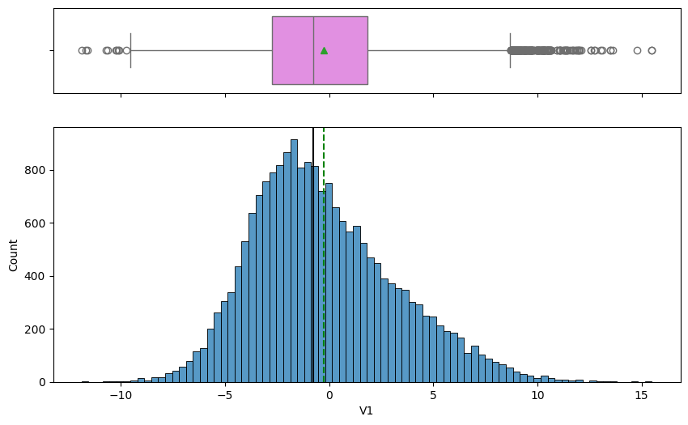

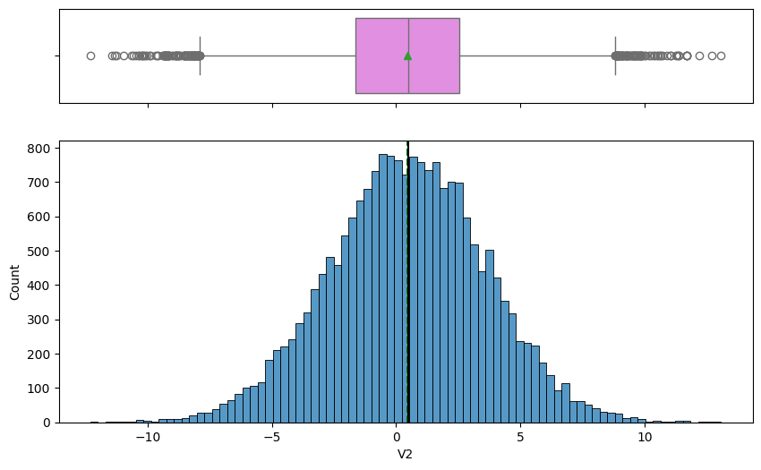

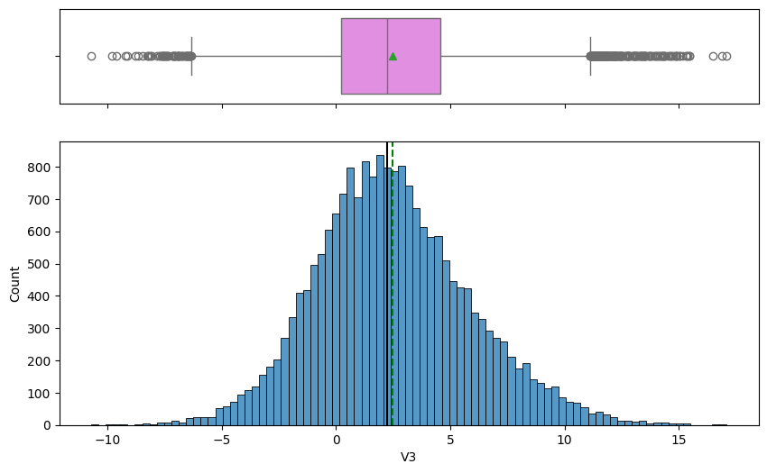

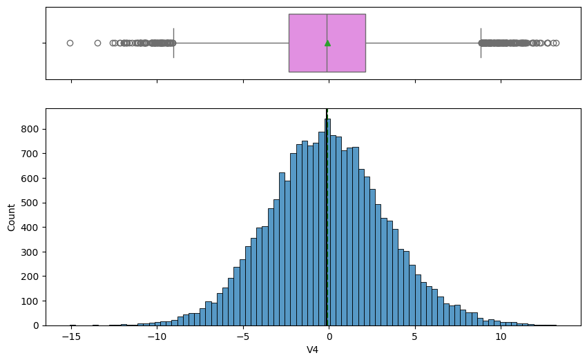

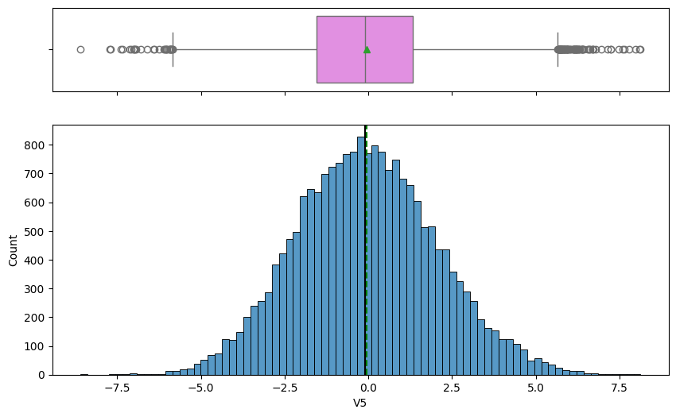

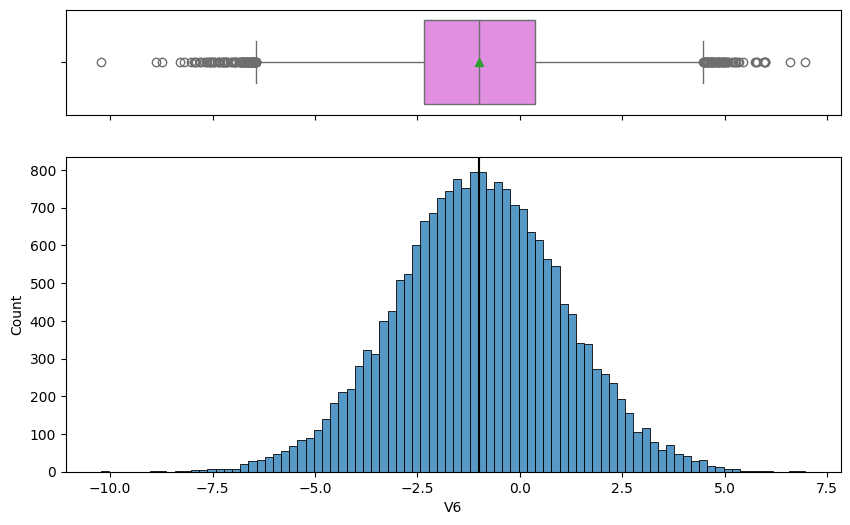

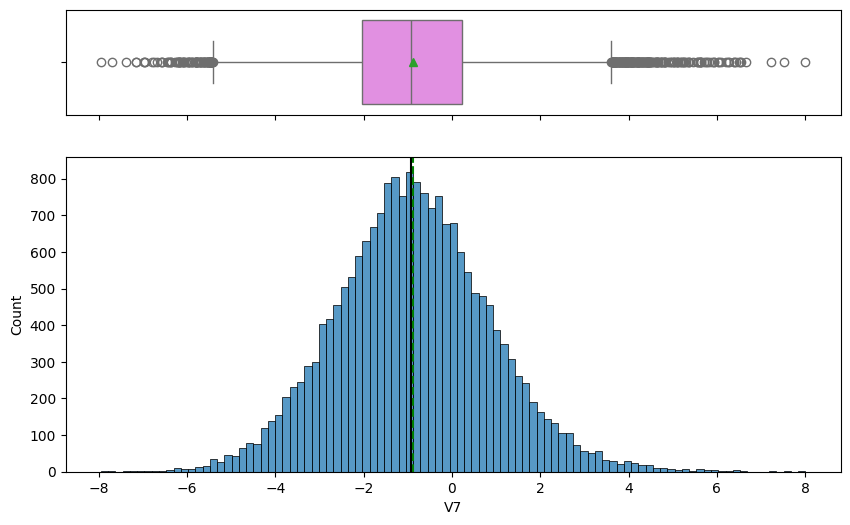

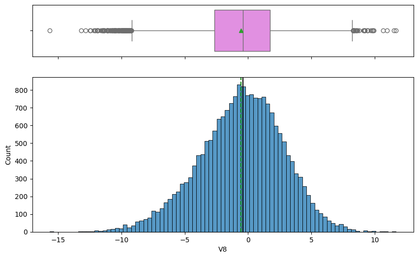

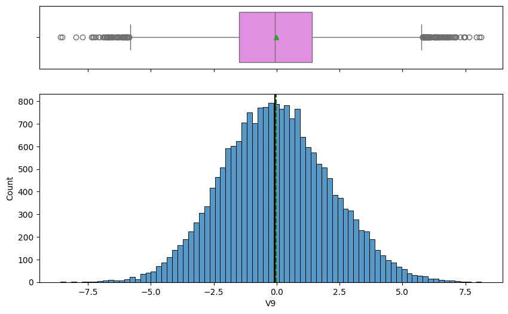

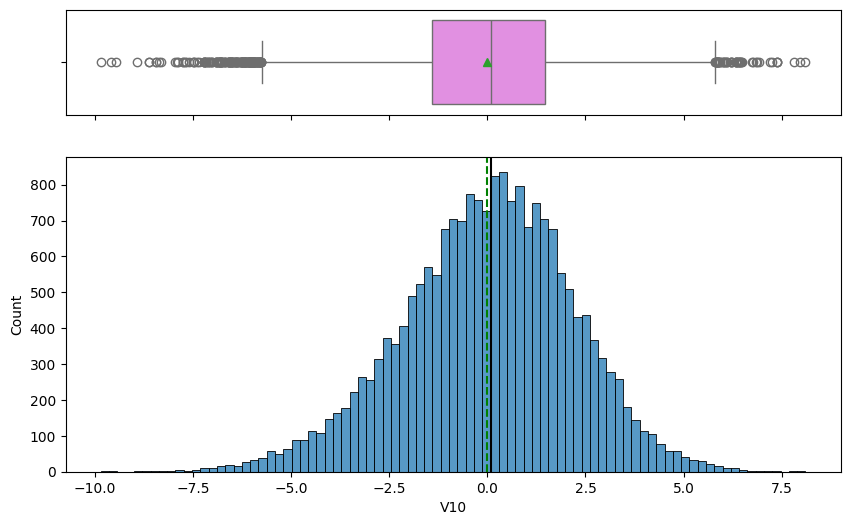

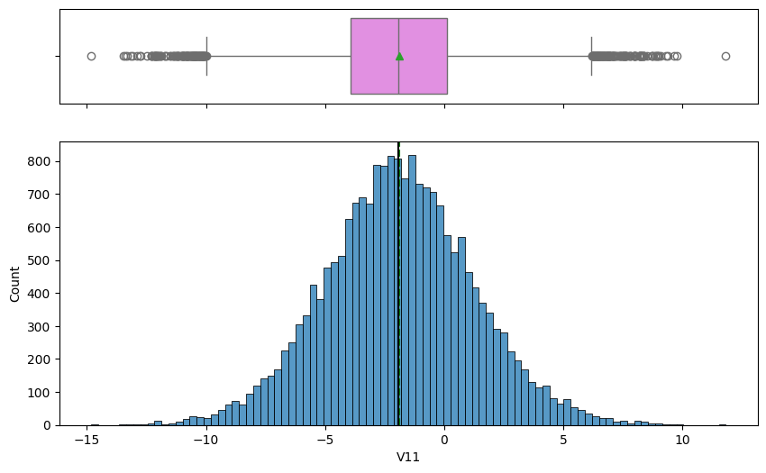

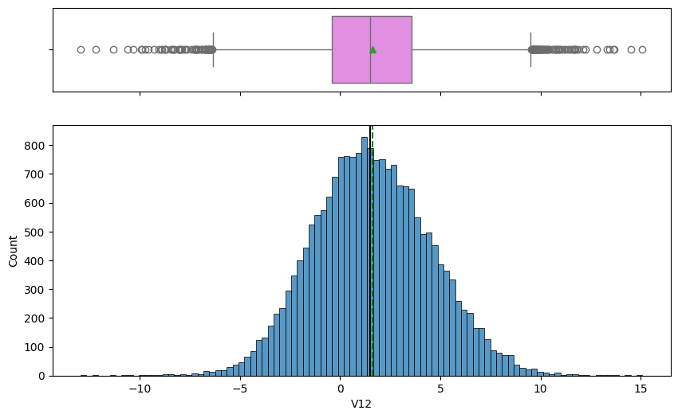

[28 more figures not shown]

```python
# List of features
features = [col for col in df.columns if col not in ['Target']]

# Plotting distribution of features using boxplots and histograms
for i in features:
  histogram_boxplot(df, i)
  print('-'*150)
```

```python
# Checking the distribution of the Target variable in train set
df['Target'].value_counts(normalize='True')
```

| Target | proportion |
| --- | --- |
| 0 | 0.9445 |
| 1 | 0.0555 |

**dtype:** float64

- There is a major class imbalance in the Target variable:
  - 94.45% of the generators have not failed
  - 5.55% of generators have failed

```python
# Checking the distribution of the Target variable in test set
df_test['Target'].value_counts(normalize='True')
```

| Target | proportion |
| --- | --- |
| 0 | 0.9436 |
| 1 | 0.0564 |

**dtype:** float64

- The test set has a similar class imbalance to the train set:
  - 94.36% of generators have not failed
  - 5.64% of generators have failed

## Bivariate Analysis

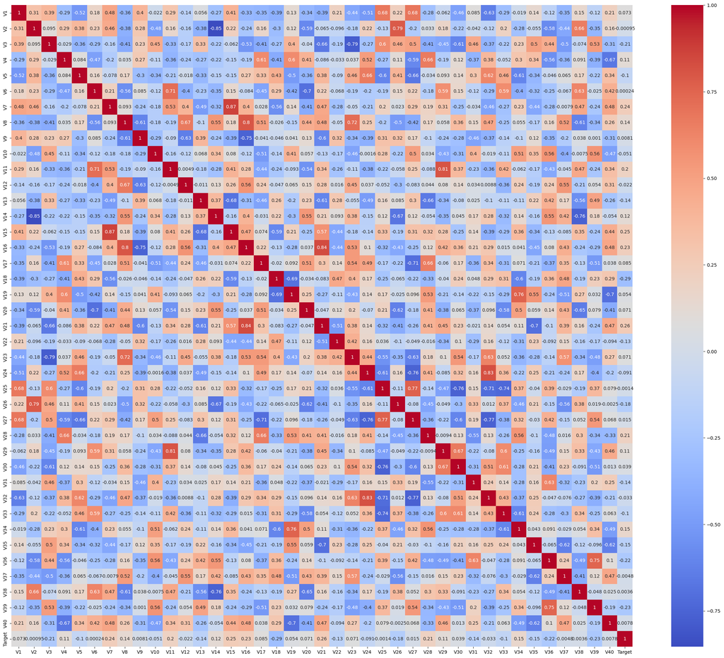

```python
# Plotting the heatmap of the variables
plt.figure(figsize=(30,25))
sns.heatmap(df.corr(), annot=True, cmap='coolwarm');
```

- Most features are weakly correlated with the Target variable, notable correlations with the Target are:
  - Positive correlations: V7(0.24), V15(0.25), V16(0.23), V21(0.26), V28(0.21).
  - Negative correlations: V3(-0.21), V18(-0.29), V36(-0.22), V39(-0.23)

# **Data Preprocessing**

```python
# Splitting dataframe into X and y
X=df.drop('Target',axis=1)
y=df['Target']
```

```python
# Splitting the test data into X_test and y_test
X_test=df_test.drop('Target',axis=1)
y_test=df_test['Target']
```

```python
# Splitting the data into train and validation sets
X_train, X_val, y_train, y_val = train_test_split(X, y, test_size=0.25, random_state=42, stratify=y)
```

- 'Stratify=y' ensures that both the train and validation sets have a similar proportion of classes in the Target variable.
- By splitting the train set (20000 observations) into train and validation sets with 'test_size=0.25' and taking into account the test dataset (5000 observations), the overall split of data is:
  - 60% train
  - 20% validation
  - 20% test

## Missing value impuation and standardization

- I am doing missing value imputation and standardization **after** the data split to order to **prevent data leakage.**

```python
# Imputing missing values with means from training set
imputer = SimpleImputer(strategy='mean')
X_train = imputer.fit_transform(X_train)
X_val = imputer.transform(X_val)
X_test = imputer.transform(X_test)
```

```python
# Initializing StandardScaler
scaler = StandardScaler()

# Standardizing the features in X_train
X_train = scaler.fit_transform(X_train) # Computes the mean and standard deviation only on the training set and applies the transformation.

# Standardizing the features in X_val
X_val = scaler.transform(X_val) # Applies the same transformation without looking at the actual values in X_val

# Standardizing the features in X_test
X_test = scaler.transform(X_test) # Applies the same transformation without looking at the actual values in X_test
```

- This ensures that the model:
  - Only learns from training data statistics.
  - Is evaluated on unseen data without contaminating the distributional assumptions.

# **Model Building**

## Model Evaluation Criterion

- Since it is given that the cost of repairing a generator is much less than the cost of replacing it, and the cost of inspection is less than the cost of repair:
  - Recall is the most appropriate evaluation criterion as false negatives (FN) are the most expensive outcome (replacement cost).
  - I want to minimize FN and therefore maximize recall.

### Utility functions

```python
# Defining function to plot loss/accuracy
def plot(history, name):
    """
    Function to plot loss/accuracy

    history: an object which stores the metrics and losses.
    name: can be one of Loss or Accuracy
    """
    fig, ax = plt.subplots() #Creating a subplot with figure and axes.
    plt.plot(history.history[name]) #Plotting the train accuracy or train loss
    plt.plot(history.history['val_'+name]) #Plotting the validation accuracy or validation loss

    plt.title('Model ' + name.capitalize()) #Defining the title of the plot.
    plt.ylabel(name.capitalize()) #Capitalizing the first letter.
    plt.xlabel('Epoch') #Defining the label for the x-axis.
    fig.legend(['Train', 'Validation'], loc="outside right upper") #Defining the legend, loc controls the position of the legend.
```

- Creating a dataframe to store the parameters and results of the models

```python
#Defining the columns of the dataframe which are nothing but the hyper parameters and the metrics.
columns = ["# hidden layers","# neurons - hidden layer","activation function - hidden layer ","# epochs","batch size","optimizer","learning rate, momentum","weight initializer","regularization","Class Weights","train loss","validation loss","train recall","validation recall","time (secs)"]

#Creating a pandas dataframe.
results = pd.DataFrame(columns=columns)
```

```python
# Setting seed for replication
keras.utils.set_random_seed(42)
```

## Initial Model Building (Model 0)

```python
# clears the current Keras session
tf.keras.backend.clear_session()

# initializing the neural network
model = Sequential()
# Adding hidden layer with ReLU activation
model.add(Dense(20,activation="relu",input_shape=(X_train.shape[1],)))
# Adding output layer with sigmoid activation for binary classification
model.add(Dense(1, activation = 'sigmoid'))

# defining SGD as the optimizer to be used
optimizer = keras.optimizers.SGD()
# Using BinaryCrossentropy loss and recall metric for binary classification
model.compile(loss=tf.keras.losses.BinaryCrossentropy(), optimizer=optimizer, metrics=["recall"])
```

```python
# Reshaping y_train to match the output shape of the model
y_train_reshaped = y_train.values.reshape(-1, 1)
y_val_reshaped = y_val.values.reshape(-1, 1)
```

```python
# Defining the batch size and number of epochs
batch_size = X_train.shape[0]
epochs = 10

# time.time() returns the time in seconds since Thu Jan 1 00:00:00 1970.
start = time.time()

# Fitting the model.
history = model.fit(
    X_train, y_train_reshaped,
    validation_data=(X_val,y_val_reshaped),
    batch_size=batch_size,
    epochs=epochs
)

# time.time() returns the time in seconds since Thu Jan 1 00:00:00 1970.
end = time.time()
```

```
1/1 ━━━━━━━━━━━━━━━━━━━━ 1s 673ms/step - loss: 0.8738 - recall: 0.5294 - val_loss: 0.8513 - val_recall: 0.5343
1/1 ━━━━━━━━━━━━━━━━━━━━ 0s 68ms/step - loss: 0.8579 - recall: 0.5222 - val_loss: 0.8359 - val_recall: 0.5271
1/1 ━━━━━━━━━━━━━━━━━━━━ 0s 69ms/step - loss: 0.8425 - recall: 0.5150 - val_loss: 0.8211 - val_recall: 0.5199
1/1 ━━━━━━━━━━━━━━━━━━━━ 0s 139ms/step - loss: 0.8276 - recall: 0.5066 - val_loss: 0.8067 - val_recall: 0.5090
1/1 ━━━━━━━━━━━━━━━━━━━━ 0s 72ms/step - loss: 0.8132 - recall: 0.4958 - val_loss: 0.7928 - val_recall: 0.4982
1/1 ━━━━━━━━━━━━━━━━━━━━ 0s 73ms/step - loss: 0.7992 - recall: 0.4874 - val_loss: 0.7793 - val_recall: 0.4910
1/1 ━━━━━━━━━━━━━━━━━━━━ 0s 127ms/step - loss: 0.7856 - recall: 0.4754 - val_loss: 0.7662 - val_recall: 0.4801
1/1 ━━━━━━━━━━━━━━━━━━━━ 0s 71ms/step - loss: 0.7725 - recall: 0.4670 - val_loss: 0.7535 - val_recall: 0.4801
1/1 ━━━━━━━━━━━━━━━━━━━━ 0s 71ms/step - loss: 0.7598 - recall: 0.4526 - val_loss: 0.7413 - val_recall: 0.4585
1/1 ━━━━━━━━━━━━━━━━━━━━ 0s 72ms/step - loss: 0.7475 - recall: 0.4454 - val_loss: 0.7293 - val_recall: 0.4440
```

```python
print("Time taken in seconds ",end-start)
```

```
Time taken in seconds  1.5225822925567627
```

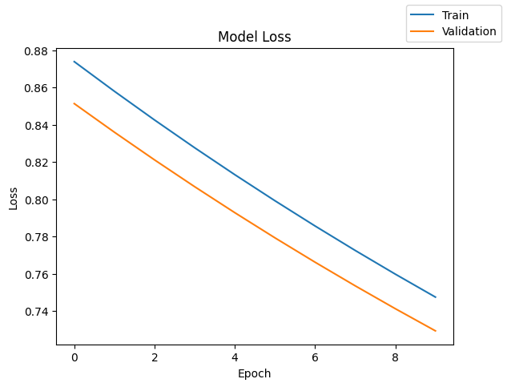

```python
plot(history,'loss')
```

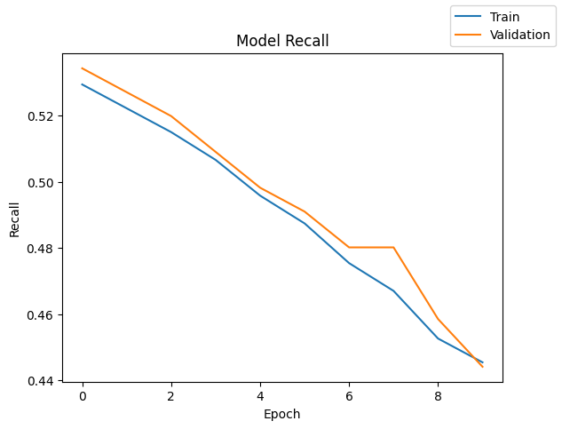

```python
plot(history,'recall')
```

```python
results.loc[0] = [1,20,'ReLU',10,15000,'SGD',None,None,None,None,history.history["loss"][-1],history.history["val_loss"][-1],history.history["recall"][-1],history.history["val_recall"][-1],round(end-start,2)]

results
```

|  | # hidden layers | # neurons - hidden layer | activation function - hidden layer | # epochs | batch size | optimizer | learning rate, momentum | weight initializer | regularization | Class Weights | train loss | validation loss | train recall | validation recall | time (secs) |
| --- | --- | --- | --- | --- | --- | --- | --- | --- | --- | --- | --- | --- | --- | --- | --- |
| 0 | 1 | 20 | ReLU | 10 | 15000 | SGD | None | None | None | None | 0.74747 | 0.729348 | 0.445378 | 0.444043 | 1.52 |

Observations Model 0:

- Loss: Both train and validation loss are decreasing linearly.
- Recall:
  - Recall is surprisingly getting worse as the number of epochs increase.
  - Recall on the validation set is slightly better than on train set
- Training time: Very quick as the batch size is the same as number of observations and only 10 epochs.

# **Model Performance Improvement**

## Model 1

- Let's make some changes:
  - Decrease the batch size to 64
  - Increase epochs to 50
  - Use SGD with momentum (0.9) as optimizer

```python
# clears the current Keras session
tf.keras.backend.clear_session()

# initializing the neural network
model1 = Sequential()
# Adding hidden layer with ReLU activation
model1.add(Dense(20,activation="relu",input_shape=(X_train.shape[1],)))
# Adding output layer with sigmoid activation for binary classification
model1.add(Dense(1, activation = 'sigmoid'))

# defining SGD with momentum as the optimizer to be used
optimizer = keras.optimizers.SGD(momentum=0.9)
# Using BinaryCrossentropy loss and recall metric for binary classification
model1.compile(loss=tf.keras.losses.BinaryCrossentropy(), optimizer=optimizer, metrics=["recall"])
```

```python
# Defining the batch size and number of epochs
batch_size = 64
epochs = 50

# time.time() returns the time in seconds since Thu Jan 1 00:00:00 1970.
start = time.time()

# Fitting the model.
history = model1.fit(
    X_train, y_train_reshaped,
    validation_data=(X_val,y_val_reshaped),
    batch_size=batch_size,
    epochs=epochs
)

# time.time() returns the time in seconds since Thu Jan 1 00:00:00 1970.
end = time.time()
```

```
235/235 ━━━━━━━━━━━━━━━━━━━━ 1s 3ms/step - loss: 0.3076 - recall: 0.2139 - val_loss: 0.1077 - val_recall: 0.4874
235/235 ━━━━━━━━━━━━━━━━━━━━ 1s 2ms/step - loss: 0.1041 - recall: 0.5199 - val_loss: 0.0884 - val_recall: 0.6173
235/235 ━━━━━━━━━━━━━━━━━━━━ 0s 2ms/step - loss: 0.0860 - recall: 0.6233 - val_loss: 0.0783 - val_recall: 0.7004
235/235 ━━━━━━━━━━━━━━━━━━━━ 1s 2ms/step - loss: 0.0755 - recall: 0.6877 - val_loss: 0.0719 - val_recall: 0.7437
235/235 ━━━━━━━━━━━━━━━━━━━━ 1s 2ms/step - loss: 0.0686 - recall: 0.7233 - val_loss: 0.0677 - val_recall: 0.7798
235/235 ━━━━━━━━━━━━━━━━━━━━ 1s 2ms/step - loss: 0.0639 - recall: 0.7554 - val_loss: 0.0650 - val_recall: 0.7978
235/235 ━━━━━━━━━━━━━━━━━━━━ 1s 2ms/step - loss: 0.0606 - recall: 0.7690 - val_loss: 0.0632 - val_recall: 0.8014
235/235 ━━━━━━━━━━━━━━━━━━━━ 0s 2ms/step - loss: 0.0582 - recall: 0.7821 - val_loss: 0.0618 - val_recall: 0.8014
235/235 ━━━━━━━━━━━━━━━━━━━━ 0s 2ms/step - loss: 0.0563 - recall: 0.7956 - val_loss: 0.0606 - val_recall: 0.8051
235/235 ━━━━━━━━━━━━━━━━━━━━ 1s 2ms/step - loss: 0.0549 - recall: 0.8050 - val_loss: 0.0596 - val_recall: 0.8195
235/235 ━━━━━━━━━━━━━━━━━━━━ 1s 2ms/step - loss: 0.0536 - recall: 0.8143 - val_loss: 0.0589 - val_recall: 0.8231
235/235 ━━━━━━━━━━━━━━━━━━━━ 0s 2ms/step - loss: 0.0527 - recall: 0.8160 - val_loss: 0.0582 - val_recall: 0.8231
235/235 ━━━━━━━━━━━━━━━━━━━━ 1s 2ms/step - loss: 0.0519 - recall: 0.8187 - val_loss: 0.0576 - val_recall: 0.8231
235/235 ━━━━━━━━━━━━━━━━━━━━ 1s 2ms/step - loss: 0.0513 - recall: 0.8189 - val_loss: 0.0570 - val_recall: 0.8303
235/235 ━━━━━━━━━━━━━━━━━━━━ 1s 2ms/step - loss: 0.0507 - recall: 0.8262 - val_loss: 0.0565 - val_recall: 0.8303
235/235 ━━━━━━━━━━━━━━━━━━━━ 1s 2ms/step - loss: 0.0502 - recall: 0.8244 - val_loss: 0.0562 - val_recall: 0.8339
235/235 ━━━━━━━━━━━━━━━━━━━━ 1s 2ms/step - loss: 0.0498 - recall: 0.8266 - val_loss: 0.0559 - val_recall: 0.8339
235/235 ━━━━━━━━━━━━━━━━━━━━ 1s 2ms/step - loss: 0.0494 - recall: 0.8286 - val_loss: 0.0556 - val_recall: 0.8339
235/235 ━━━━━━━━━━━━━━━━━━━━ 1s 2ms/step - loss: 0.0490 - recall: 0.8303 - val_loss: 0.0554 - val_recall: 0.8339
235/235 ━━━━━━━━━━━━━━━━━━━━ 1s 3ms/step - loss: 0.0487 - recall: 0.8308 - val_loss: 0.0551 - val_recall: 0.8303
235/235 ━━━━━━━━━━━━━━━━━━━━ 1s 2ms/step - loss: 0.0484 - recall: 0.8311 - val_loss: 0.0550 - val_recall: 0.8339
235/235 ━━━━━━━━━━━━━━━━━━━━ 1s 2ms/step - loss: 0.0481 - recall: 0.8350 - val_loss: 0.0548 - val_recall: 0.8339
235/235 ━━━━━━━━━━━━━━━━━━━━ 0s 2ms/step - loss: 0.0478 - recall: 0.8350 - val_loss: 0.0547 - val_recall: 0.8339
235/235 ━━━━━━━━━━━━━━━━━━━━ 1s 2ms/step - loss: 0.0476 - recall: 0.8379 - val_loss: 0.0546 - val_recall: 0.8339
235/235 ━━━━━━━━━━━━━━━━━━━━ 1s 2ms/step - loss: 0.0473 - recall: 0.8379 - val_loss: 0.0546 - val_recall: 0.8375
235/235 ━━━━━━━━━━━━━━━━━━━━ 0s 2ms/step - loss: 0.0472 - recall: 0.8351 - val_loss: 0.0545 - val_recall: 0.8339
235/235 ━━━━━━━━━━━━━━━━━━━━ 0s 2ms/step - loss: 0.0470 - recall: 0.8425 - val_loss: 0.0544 - val_recall: 0.8339
235/235 ━━━━━━━━━━━━━━━━━━━━ 0s 2ms/step - loss: 0.0468 - recall: 0.8401 - val_loss: 0.0544 - val_recall: 0.8375
235/235 ━━━━━━━━━━━━━━━━━━━━ 1s 2ms/step - loss: 0.0467 - recall: 0.8429 - val_loss: 0.0545 - val_recall: 0.8375
235/235 ━━━━━━━━━━━━━━━━━━━━ 1s 2ms/step - loss: 0.0465 - recall: 0.8422 - val_loss: 0.0544 - val_recall: 0.8375
235/235 ━━━━━━━━━━━━━━━━━━━━ 0s 2ms/step - loss: 0.0463 - recall: 0.8439 - val_loss: 0.0544 - val_recall: 0.8375
235/235 ━━━━━━━━━━━━━━━━━━━━ 1s 2ms/step - loss: 0.0461 - recall: 0.8429 - val_loss: 0.0542 - val_recall: 0.8412
235/235 ━━━━━━━━━━━━━━━━━━━━ 0s 2ms/step - loss: 0.0460 - recall: 0.8439 - val_loss: 0.0542 - val_recall: 0.8412
235/235 ━━━━━━━━━━━━━━━━━━━━ 1s 2ms/step - loss: 0.0458 - recall: 0.8439 - val_loss: 0.0542 - val_recall: 0.8412
235/235 ━━━━━━━━━━━━━━━━━━━━ 1s 2ms/step - loss: 0.0457 - recall: 0.8505 - val_loss: 0.0541 - val_recall: 0.8412
235/235 ━━━━━━━━━━━━━━━━━━━━ 1s 2ms/step - loss: 0.0455 - recall: 0.8486 - val_loss: 0.0541 - val_recall: 0.8375
235/235 ━━━━━━━━━━━━━━━━━━━━ 1s 2ms/step - loss: 0.0454 - recall: 0.8480 - val_loss: 0.0540 - val_recall: 0.8375
235/235 ━━━━━━━━━━━━━━━━━━━━ 0s 2ms/step - loss: 0.0453 - recall: 0.8484 - val_loss: 0.0540 - val_recall: 0.8375
235/235 ━━━━━━━━━━━━━━━━━━━━ 1s 2ms/step - loss: 0.0451 - recall: 0.8523 - val_loss: 0.0539 - val_recall: 0.8375
235/235 ━━━━━━━━━━━━━━━━━━━━ 1s 2ms/step - loss: 0.0449 - recall: 0.8575 - val_loss: 0.0539 - val_recall: 0.8375
235/235 ━━━━━━━━━━━━━━━━━━━━ 1s 2ms/step - loss: 0.0448 - recall: 0.8575 - val_loss: 0.0537 - val_recall: 0.8375
235/235 ━━━━━━━━━━━━━━━━━━━━ 0s 2ms/step - loss: 0.0447 - recall: 0.8587 - val_loss: 0.0537 - val_recall: 0.8375
235/235 ━━━━━━━━━━━━━━━━━━━━ 1s 2ms/step - loss: 0.0445 - recall: 0.8559 - val_loss: 0.0536 - val_recall: 0.8375
235/235 ━━━━━━━━━━━━━━━━━━━━ 1s 2ms/step - loss: 0.0444 - recall: 0.8559 - val_loss: 0.0536 - val_recall: 0.8375
235/235 ━━━━━━━━━━━━━━━━━━━━ 1s 2ms/step - loss: 0.0442 - recall: 0.8559 - val_loss: 0.0535 - val_recall: 0.8375
235/235 ━━━━━━━━━━━━━━━━━━━━ 0s 2ms/step - loss: 0.0441 - recall: 0.8567 - val_loss: 0.0535 - val_recall: 0.8375
235/235 ━━━━━━━━━━━━━━━━━━━━ 1s 2ms/step - loss: 0.0440 - recall: 0.8581 - val_loss: 0.0534 - val_recall: 0.8412
235/235 ━━━━━━━━━━━━━━━━━━━━ 1s 2ms/step - loss: 0.0439 - recall: 0.8604 - val_loss: 0.0534 - val_recall: 0.8412
235/235 ━━━━━━━━━━━━━━━━━━━━ 0s 2ms/step - loss: 0.0438 - recall: 0.8590 - val_loss: 0.0533 - val_recall: 0.8412
235/235 ━━━━━━━━━━━━━━━━━━━━ 1s 2ms/step - loss: 0.0436 - recall: 0.8542 - val_loss: 0.0532 - val_recall: 0.8412
```

```python
print("Time taken in seconds ",end-start)
```

```
Time taken in seconds  30.180956840515137
```

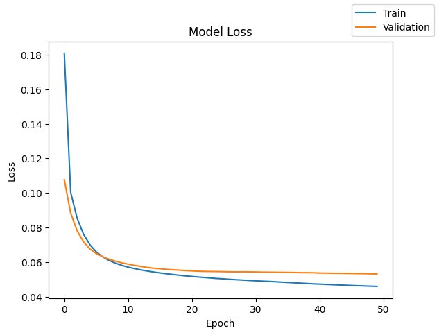

```python
plot(history,'loss')
```

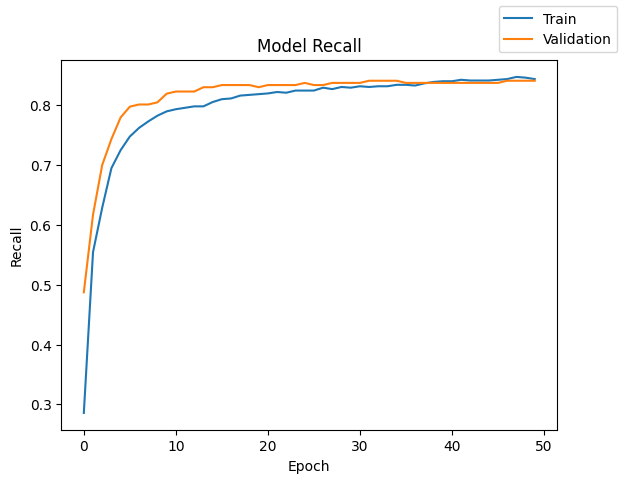

```python
plot(history,'recall')
```

```python
results.loc[1] = [1,20,'ReLU',50,64,'SGD w/ Momentum','[-, 0.9]',None,None,None,history.history["loss"][-1],history.history["val_loss"][-1],history.history["recall"][-1],history.history["val_recall"][-1],round(end-start,2)]

results
```

|  | # hidden layers | # neurons - hidden layer | activation function - hidden layer | # epochs | batch size | optimizer | learning rate, momentum | weight initializer | regularization | Class Weights | train loss | validation loss | train recall | validation recall | time (secs) |
| --- | --- | --- | --- | --- | --- | --- | --- | --- | --- | --- | --- | --- | --- | --- | --- |
| 0 | 1 | 20 | ReLU | 10 | 15000 | SGD | None | None | None | None | 0.747470 | 0.729348 | 0.445378 | 0.444043 | 1.52 |
| 1 | 1 | 20 | ReLU | 50 | 64 | SGD w/ Momentum | [-, 0.9] | None | None | None | 0.046026 | 0.053223 | 0.843938 | 0.841155 | 30.18 |

## Model 2

- Changes:
  - Adding learning rate of 0.0001
  - Change momentum to 0.8
  - Adding another hidden layer (10 nodes)

```python
# clears the current Keras session
tf.keras.backend.clear_session()

# initializing the neural network
model2 = Sequential()
# Adding hidden layer with ReLU activation
model2.add(Dense(20,activation="relu",input_shape=(X_train.shape[1],)))
# Adding 2nd hidden layer with ReLU activation
model2.add(Dense(10,activation="relu"))
# Adding output layer with sigmoid activation for binary classification
model2.add(Dense(1, activation = 'sigmoid'))

# defining SGD with momentum as the optimizer to be used
optimizer = keras.optimizers.SGD(momentum=0.8,learning_rate=0.0001)
# Using BinaryCrossentropy loss and recall metric for binary classification
model2.compile(loss=tf.keras.losses.BinaryCrossentropy(), optimizer=optimizer, metrics=["recall"])
```

```python
# Defining the batch size and number of epochs
batch_size = 64
epochs = 50

# time.time() returns the time in seconds since Thu Jan 1 00:00:00 1970.
start = time.time()

# Fitting the model.
history = model2.fit(
    X_train, y_train_reshaped,
    validation_data=(X_val,y_val_reshaped),
    batch_size=batch_size,
    epochs=epochs
)

# time.time() returns the time in seconds since Thu Jan 1 00:00:00 1970.
end = time.time()
```

```
235/235 ━━━━━━━━━━━━━━━━━━━━ 1s 2ms/step - loss: 0.8897 - recall: 0.8368 - val_loss: 0.6770 - val_recall: 0.7292
235/235 ━━━━━━━━━━━━━━━━━━━━ 0s 2ms/step - loss: 0.6287 - recall: 0.6866 - val_loss: 0.5227 - val_recall: 0.5271
235/235 ━━━━━━━━━━━━━━━━━━━━ 1s 2ms/step - loss: 0.4984 - recall: 0.4581 - val_loss: 0.4364 - val_recall: 0.3646
235/235 ━━━━━━━━━━━━━━━━━━━━ 1s 2ms/step - loss: 0.4235 - recall: 0.2188 - val_loss: 0.3822 - val_recall: 0.2238
235/235 ━━━━━━━━━━━━━━━━━━━━ 1s 2ms/step - loss: 0.3753 - recall: 0.1168 - val_loss: 0.3453 - val_recall: 0.1300
235/235 ━━━━━━━━━━━━━━━━━━━━ 1s 2ms/step - loss: 0.3420 - recall: 0.0832 - val_loss: 0.3185 - val_recall: 0.0758
235/235 ━━━━━━━━━━━━━━━━━━━━ 1s 3ms/step - loss: 0.3176 - recall: 0.0544 - val_loss: 0.2982 - val_recall: 0.0578
235/235 ━━━━━━━━━━━━━━━━━━━━ 1s 2ms/step - loss: 0.2989 - recall: 0.0387 - val_loss: 0.2822 - val_recall: 0.0397
235/235 ━━━━━━━━━━━━━━━━━━━━ 1s 3ms/step - loss: 0.2841 - recall: 0.0368 - val_loss: 0.2694 - val_recall: 0.0253
235/235 ━━━━━━━━━━━━━━━━━━━━ 0s 2ms/step - loss: 0.2720 - recall: 0.0273 - val_loss: 0.2588 - val_recall: 0.0181
235/235 ━━━━━━━━━━━━━━━━━━━━ 1s 2ms/step - loss: 0.2619 - recall: 0.0224 - val_loss: 0.2498 - val_recall: 0.0181
235/235 ━━━━━━━━━━━━━━━━━━━━ 0s 2ms/step - loss: 0.2533 - recall: 0.0152 - val_loss: 0.2422 - val_recall: 0.0144
235/235 ━━━━━━━━━━━━━━━━━━━━ 0s 2ms/step - loss: 0.2459 - recall: 0.0092 - val_loss: 0.2355 - val_recall: 0.0144
235/235 ━━━━━━━━━━━━━━━━━━━━ 1s 2ms/step - loss: 0.2394 - recall: 0.0092 - val_loss: 0.2297 - val_recall: 0.0144
235/235 ━━━━━━━━━━━━━━━━━━━━ 0s 2ms/step - loss: 0.2336 - recall: 0.0080 - val_loss: 0.2244 - val_recall: 0.0144
235/235 ━━━━━━━━━━━━━━━━━━━━ 0s 2ms/step - loss: 0.2283 - recall: 0.0078 - val_loss: 0.2197 - val_recall: 0.0144
235/235 ━━━━━━━━━━━━━━━━━━━━ 0s 2ms/step - loss: 0.2236 - recall: 0.0100 - val_loss: 0.2154 - val_recall: 0.0108
235/235 ━━━━━━━━━━━━━━━━━━━━ 1s 2ms/step - loss: 0.2192 - recall: 0.0071 - val_loss: 0.2115 - val_recall: 0.0108
235/235 ━━━━━━━━━━━━━━━━━━━━ 0s 2ms/step - loss: 0.2152 - recall: 0.0071 - val_loss: 0.2079 - val_recall: 0.0108
235/235 ━━━━━━━━━━━━━━━━━━━━ 1s 2ms/step - loss: 0.2114 - recall: 0.0071 - val_loss: 0.2046 - val_recall: 0.0144
235/235 ━━━━━━━━━━━━━━━━━━━━ 0s 2ms/step - loss: 0.2079 - recall: 0.0071 - val_loss: 0.2014 - val_recall: 0.0144
235/235 ━━━━━━━━━━━━━━━━━━━━ 0s 2ms/step - loss: 0.2046 - recall: 0.0080 - val_loss: 0.1985 - val_recall: 0.0144
235/235 ━━━━━━━━━━━━━━━━━━━━ 1s 2ms/step - loss: 0.2015 - recall: 0.0092 - val_loss: 0.1958 - val_recall: 0.0181
235/235 ━━━━━━━━━━━━━━━━━━━━ 1s 2ms/step - loss: 0.1985 - recall: 0.0092 - val_loss: 0.1931 - val_recall: 0.0217
235/235 ━━━━━━━━━━━━━━━━━━━━ 1s 2ms/step - loss: 0.1957 - recall: 0.0127 - val_loss: 0.1907 - val_recall: 0.0217
235/235 ━━━━━━━━━━━━━━━━━━━━ 0s 2ms/step - loss: 0.1931 - recall: 0.0142 - val_loss: 0.1883 - val_recall: 0.0217
235/235 ━━━━━━━━━━━━━━━━━━━━ 1s 2ms/step - loss: 0.1905 - recall: 0.0144 - val_loss: 0.1861 - val_recall: 0.0217
235/235 ━━━━━━━━━━━━━━━━━━━━ 1s 2ms/step - loss: 0.1881 - recall: 0.0197 - val_loss: 0.1839 - val_recall: 0.0217
235/235 ━━━━━━━━━━━━━━━━━━━━ 1s 3ms/step - loss: 0.1858 - recall: 0.0197 - val_loss: 0.1819 - val_recall: 0.0253
235/235 ━━━━━━━━━━━━━━━━━━━━ 1s 2ms/step - loss: 0.1836 - recall: 0.0225 - val_loss: 0.1800 - val_recall: 0.0325
235/235 ━━━━━━━━━━━━━━━━━━━━ 1s 2ms/step - loss: 0.1815 - recall: 0.0232 - val_loss: 0.1781 - val_recall: 0.0361
235/235 ━━━━━━━━━━━━━━━━━━━━ 0s 2ms/step - loss: 0.1794 - recall: 0.0236 - val_loss: 0.1763 - val_recall: 0.0361
235/235 ━━━━━━━━━━━━━━━━━━━━ 1s 2ms/step - loss: 0.1774 - recall: 0.0237 - val_loss: 0.1746 - val_recall: 0.0397
235/235 ━━━━━━━━━━━━━━━━━━━━ 1s 2ms/step - loss: 0.1756 - recall: 0.0254 - val_loss: 0.1729 - val_recall: 0.0433
235/235 ━━━━━━━━━━━━━━━━━━━━ 0s 2ms/step - loss: 0.1738 - recall: 0.0254 - val_loss: 0.1713 - val_recall: 0.0469
235/235 ━━━━━━━━━━━━━━━━━━━━ 0s 2ms/step - loss: 0.1720 - recall: 0.0362 - val_loss: 0.1698 - val_recall: 0.0505
235/235 ━━━━━━━━━━━━━━━━━━━━ 0s 2ms/step - loss: 0.1704 - recall: 0.0394 - val_loss: 0.1684 - val_recall: 0.0578
235/235 ━━━━━━━━━━━━━━━━━━━━ 1s 2ms/step - loss: 0.1688 - recall: 0.0489 - val_loss: 0.1670 - val_recall: 0.0650
235/235 ━━━━━━━━━━━━━━━━━━━━ 1s 2ms/step - loss: 0.1672 - recall: 0.0562 - val_loss: 0.1656 - val_recall: 0.0686
235/235 ━━━━━━━━━━━━━━━━━━━━ 0s 2ms/step - loss: 0.1658 - recall: 0.0623 - val_loss: 0.1643 - val_recall: 0.0794
235/235 ━━━━━━━━━━━━━━━━━━━━ 1s 2ms/step - loss: 0.1643 - recall: 0.0705 - val_loss: 0.1630 - val_recall: 0.0903
235/235 ━━━━━━━━━━━━━━━━━━━━ 0s 2ms/step - loss: 0.1630 - recall: 0.0779 - val_loss: 0.1618 - val_recall: 0.1011
235/235 ━━━━━━━━━━━━━━━━━━━━ 0s 2ms/step - loss: 0.1616 - recall: 0.0850 - val_loss: 0.1606 - val_recall: 0.1011
235/235 ━━━━━━━━━━━━━━━━━━━━ 1s 2ms/step - loss: 0.1604 - recall: 0.0891 - val_loss: 0.1595 - val_recall: 0.1047
235/235 ━━━━━━━━━━━━━━━━━━━━ 1s 2ms/step - loss: 0.1591 - recall: 0.0934 - val_loss: 0.1583 - val_recall: 0.1083
235/235 ━━━━━━━━━━━━━━━━━━━━ 0s 2ms/step - loss: 0.1579 - recall: 0.1085 - val_loss: 0.1573 - val_recall: 0.1227
235/235 ━━━━━━━━━━━━━━━━━━━━ 0s 2ms/step - loss: 0.1568 - recall: 0.1195 - val_loss: 0.1562 - val_recall: 0.1372
235/235 ━━━━━━━━━━━━━━━━━━━━ 1s 2ms/step - loss: 0.1557 - recall: 0.1338 - val_loss: 0.1552 - val_recall: 0.1444
235/235 ━━━━━━━━━━━━━━━━━━━━ 1s 2ms/step - loss: 0.1546 - recall: 0.1488 - val_loss: 0.1542 - val_recall: 0.1444
235/235 ━━━━━━━━━━━━━━━━━━━━ 1s 3ms/step - loss: 0.1536 - recall: 0.1548 - val_loss: 0.1533 - val_recall: 0.1444
```

```python
print("Time taken in seconds ",end-start)
```

```
Time taken in seconds  29.346367359161377
```

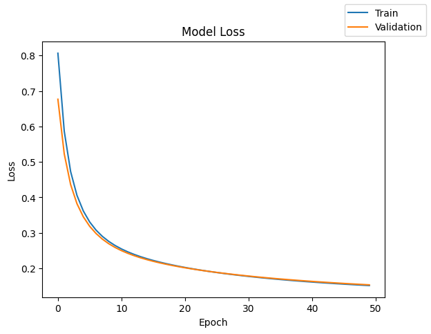

```python
plot(history,'loss')
```

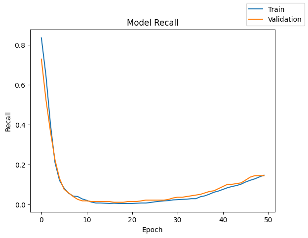

```python
plot(history,'recall')
```

```python
results.loc[2] = [2,'[20,10]','[ReLU,ReLU]',50,64,'SGD w/ Momentum','[0.0001, 0.8]',None,None,None,history.history["loss"][-1],history.history["val_loss"][-1],history.history["recall"][-1],history.history["val_recall"][-1],round(end-start,2)]

results
```

|  | # hidden layers | # neurons - hidden layer | activation function - hidden layer | # epochs | batch size | optimizer | learning rate, momentum | weight initializer | regularization | Class Weights | train loss | validation loss | train recall | validation recall | time (secs) |
| --- | --- | --- | --- | --- | --- | --- | --- | --- | --- | --- | --- | --- | --- | --- | --- |
| 0 | 1 | 20 | ReLU | 10 | 15000 | SGD | None | None | None | None | 0.747470 | 0.729348 | 0.445378 | 0.444043 | 1.52 |
| 1 | 1 | 20 | ReLU | 50 | 64 | SGD w/ Momentum | [-, 0.9] | None | None | None | 0.046026 | 0.053223 | 0.843938 | 0.841155 | 30.18 |
| 2 | 2 | [20,10] | [ReLU,ReLU] | 50 | 64 | SGD w/ Momentum | [0.0001, 0.8] | None | None | None | 0.151322 | 0.153274 | 0.146459 | 0.144404 | 29.35 |

Observations Model 2:

- Loss:
  - The loss function has been somewhat minimized.
  - The This model has a lower loss than model 0 however it is larger than model 1.
  - The loss on train and validation are similar which indicates good generalization.
- Recall:
  - This model performed very poorly on recall
  - Recall plummeted as the epochs increased and almost reached 0 at around the 20th epoch. However recall started to improve and increase at around the 30th epoch. It would likely continue to improve if the model iterated through more epochs.
- Training time:
  - Similar to model 1.
  - Adding one layer did not seem to drastically increase training time.

## Model 3

- Changes:
  - Using Adam as optimizer
  - Increase learning rate to 0.001

```python
# clears the current Keras session
tf.keras.backend.clear_session()

# initializing the neural network
model3 = Sequential()
# Adding hidden layer with ReLU activation
model3.add(Dense(20,activation="relu",input_shape=(X_train.shape[1],)))
# Adding 2nd hidden layer with ReLU activation
model3.add(Dense(10,activation="relu"))
# Adding output layer with sigmoid activation for binary classification
model3.add(Dense(1, activation = 'sigmoid'))

# defining Adam as the optimizer to be used
optimizer = keras.optimizers.Adam(learning_rate=0.001)
# Using BinaryCrossentropy loss and recall metric for binary classification
model3.compile(loss=tf.keras.losses.BinaryCrossentropy(), optimizer=optimizer, metrics=["recall"])
```

```python
# Defining the batch size and number of epochs
batch_size = 64
epochs = 50

# time.time() returns the time in seconds since Thu Jan 1 00:00:00 1970.
start = time.time()

# Fitting the model.
history = model3.fit(
    X_train, y_train_reshaped,
    validation_data=(X_val,y_val_reshaped),
    batch_size=batch_size,
    epochs=epochs
)

# time.time() returns the time in seconds since Thu Jan 1 00:00:00 1970.
end = time.time()
```

```
235/235 ━━━━━━━━━━━━━━━━━━━━ 2s 3ms/step - loss: 0.4560 - recall: 0.2015 - val_loss: 0.1370 - val_recall: 0.2202
235/235 ━━━━━━━━━━━━━━━━━━━━ 1s 2ms/step - loss: 0.1248 - recall: 0.4185 - val_loss: 0.0975 - val_recall: 0.6173
235/235 ━━━━━━━━━━━━━━━━━━━━ 0s 2ms/step - loss: 0.0946 - recall: 0.5990 - val_loss: 0.0815 - val_recall: 0.7148
235/235 ━━━━━━━━━━━━━━━━━━━━ 1s 2ms/step - loss: 0.0779 - recall: 0.6793 - val_loss: 0.0714 - val_recall: 0.7834
235/235 ━━━━━━━━━━━━━━━━━━━━ 1s 2ms/step - loss: 0.0672 - recall: 0.7479 - val_loss: 0.0649 - val_recall: 0.8339
235/235 ━━━━━━━━━━━━━━━━━━━━ 1s 2ms/step - loss: 0.0605 - recall: 0.7901 - val_loss: 0.0610 - val_recall: 0.8556
235/235 ━━━━━━━━━━━━━━━━━━━━ 1s 2ms/step - loss: 0.0561 - recall: 0.8063 - val_loss: 0.0587 - val_recall: 0.8700
235/235 ━━━━━━━━━━━━━━━━━━━━ 1s 2ms/step - loss: 0.0530 - recall: 0.8216 - val_loss: 0.0570 - val_recall: 0.8736
235/235 ━━━━━━━━━━━━━━━━━━━━ 0s 2ms/step - loss: 0.0505 - recall: 0.8364 - val_loss: 0.0556 - val_recall: 0.8736
235/235 ━━━━━━━━━━━━━━━━━━━━ 1s 2ms/step - loss: 0.0486 - recall: 0.8442 - val_loss: 0.0543 - val_recall: 0.8700
235/235 ━━━━━━━━━━━━━━━━━━━━ 0s 2ms/step - loss: 0.0470 - recall: 0.8531 - val_loss: 0.0534 - val_recall: 0.8700
235/235 ━━━━━━━━━━━━━━━━━━━━ 0s 2ms/step - loss: 0.0456 - recall: 0.8611 - val_loss: 0.0524 - val_recall: 0.8736
235/235 ━━━━━━━━━━━━━━━━━━━━ 0s 2ms/step - loss: 0.0445 - recall: 0.8636 - val_loss: 0.0516 - val_recall: 0.8736
235/235 ━━━━━━━━━━━━━━━━━━━━ 1s 2ms/step - loss: 0.0435 - recall: 0.8652 - val_loss: 0.0507 - val_recall: 0.8809
235/235 ━━━━━━━━━━━━━━━━━━━━ 1s 3ms/step - loss: 0.0427 - recall: 0.8663 - val_loss: 0.0500 - val_recall: 0.8809
235/235 ━━━━━━━━━━━━━━━━━━━━ 1s 2ms/step - loss: 0.0418 - recall: 0.8709 - val_loss: 0.0492 - val_recall: 0.8809
235/235 ━━━━━━━━━━━━━━━━━━━━ 1s 2ms/step - loss: 0.0411 - recall: 0.8759 - val_loss: 0.0484 - val_recall: 0.8809
235/235 ━━━━━━━━━━━━━━━━━━━━ 0s 2ms/step - loss: 0.0404 - recall: 0.8762 - val_loss: 0.0482 - val_recall: 0.8917
235/235 ━━━━━━━━━━━━━━━━━━━━ 1s 2ms/step - loss: 0.0399 - recall: 0.8766 - val_loss: 0.0479 - val_recall: 0.8917
235/235 ━━━━━━━━━━━━━━━━━━━━ 0s 2ms/step - loss: 0.0395 - recall: 0.8766 - val_loss: 0.0477 - val_recall: 0.8917
235/235 ━━━━━━━━━━━━━━━━━━━━ 1s 2ms/step - loss: 0.0390 - recall: 0.8784 - val_loss: 0.0476 - val_recall: 0.8917
235/235 ━━━━━━━━━━━━━━━━━━━━ 1s 2ms/step - loss: 0.0387 - recall: 0.8811 - val_loss: 0.0474 - val_recall: 0.8953
235/235 ━━━━━━━━━━━━━━━━━━━━ 1s 2ms/step - loss: 0.0384 - recall: 0.8838 - val_loss: 0.0471 - val_recall: 0.8881
235/235 ━━━━━━━━━━━━━━━━━━━━ 1s 2ms/step - loss: 0.0380 - recall: 0.8858 - val_loss: 0.0469 - val_recall: 0.8953
235/235 ━━━━━━━━━━━━━━━━━━━━ 0s 2ms/step - loss: 0.0378 - recall: 0.8858 - val_loss: 0.0468 - val_recall: 0.8989
235/235 ━━━━━━━━━━━━━━━━━━━━ 1s 3ms/step - loss: 0.0374 - recall: 0.8869 - val_loss: 0.0465 - val_recall: 0.8989
235/235 ━━━━━━━━━━━━━━━━━━━━ 0s 2ms/step - loss: 0.0371 - recall: 0.8858 - val_loss: 0.0465 - val_recall: 0.8989
235/235 ━━━━━━━━━━━━━━━━━━━━ 0s 2ms/step - loss: 0.0368 - recall: 0.8881 - val_loss: 0.0463 - val_recall: 0.8989
235/235 ━━━━━━━━━━━━━━━━━━━━ 1s 2ms/step - loss: 0.0365 - recall: 0.8925 - val_loss: 0.0461 - val_recall: 0.8989
235/235 ━━━━━━━━━━━━━━━━━━━━ 1s 2ms/step - loss: 0.0363 - recall: 0.8925 - val_loss: 0.0458 - val_recall: 0.8989
235/235 ━━━━━━━━━━━━━━━━━━━━ 0s 2ms/step - loss: 0.0361 - recall: 0.8926 - val_loss: 0.0457 - val_recall: 0.8989
235/235 ━━━━━━━━━━━━━━━━━━━━ 1s 2ms/step - loss: 0.0358 - recall: 0.8932 - val_loss: 0.0456 - val_recall: 0.8989
235/235 ━━━━━━━━━━━━━━━━━━━━ 0s 2ms/step - loss: 0.0357 - recall: 0.8932 - val_loss: 0.0452 - val_recall: 0.9025
235/235 ━━━━━━━━━━━━━━━━━━━━ 1s 2ms/step - loss: 0.0355 - recall: 0.8982 - val_loss: 0.0451 - val_recall: 0.9025
235/235 ━━━━━━━━━━━━━━━━━━━━ 1s 3ms/step - loss: 0.0354 - recall: 0.8927 - val_loss: 0.0450 - val_recall: 0.9025
235/235 ━━━━━━━━━━━━━━━━━━━━ 1s 3ms/step - loss: 0.0352 - recall: 0.8982 - val_loss: 0.0447 - val_recall: 0.9025
235/235 ━━━━━━━━━━━━━━━━━━━━ 1s 2ms/step - loss: 0.0350 - recall: 0.8987 - val_loss: 0.0446 - val_recall: 0.9025
235/235 ━━━━━━━━━━━━━━━━━━━━ 1s 2ms/step - loss: 0.0349 - recall: 0.9039 - val_loss: 0.0444 - val_recall: 0.9025
235/235 ━━━━━━━━━━━━━━━━━━━━ 0s 2ms/step - loss: 0.0347 - recall: 0.8985 - val_loss: 0.0442 - val_recall: 0.9061
235/235 ━━━━━━━━━━━━━━━━━━━━ 0s 2ms/step - loss: 0.0345 - recall: 0.9038 - val_loss: 0.0442 - val_recall: 0.9061
235/235 ━━━━━━━━━━━━━━━━━━━━ 0s 2ms/step - loss: 0.0344 - recall: 0.9054 - val_loss: 0.0441 - val_recall: 0.9025
235/235 ━━━━━━━━━━━━━━━━━━━━ 1s 2ms/step - loss: 0.0344 - recall: 0.9087 - val_loss: 0.0440 - val_recall: 0.9025
235/235 ━━━━━━━━━━━━━━━━━━━━ 0s 2ms/step - loss: 0.0342 - recall: 0.9076 - val_loss: 0.0439 - val_recall: 0.9061
235/235 ━━━━━━━━━━━━━━━━━━━━ 1s 2ms/step - loss: 0.0340 - recall: 0.9076 - val_loss: 0.0437 - val_recall: 0.9061
235/235 ━━━━━━━━━━━━━━━━━━━━ 1s 2ms/step - loss: 0.0340 - recall: 0.9075 - val_loss: 0.0437 - val_recall: 0.9061
235/235 ━━━━━━━━━━━━━━━━━━━━ 0s 2ms/step - loss: 0.0339 - recall: 0.9061 - val_loss: 0.0437 - val_recall: 0.9061
235/235 ━━━━━━━━━━━━━━━━━━━━ 0s 2ms/step - loss: 0.0338 - recall: 0.9109 - val_loss: 0.0435 - val_recall: 0.9061
235/235 ━━━━━━━━━━━━━━━━━━━━ 1s 2ms/step - loss: 0.0337 - recall: 0.9075 - val_loss: 0.0433 - val_recall: 0.9061
235/235 ━━━━━━━━━━━━━━━━━━━━ 0s 2ms/step - loss: 0.0336 - recall: 0.9111 - val_loss: 0.0432 - val_recall: 0.9061
235/235 ━━━━━━━━━━━━━━━━━━━━ 1s 2ms/step - loss: 0.0335 - recall: 0.9122 - val_loss: 0.0431 - val_recall: 0.9061
```

```python
print("Time taken in seconds ",end-start)
```

```
Time taken in seconds  31.19696307182312
```

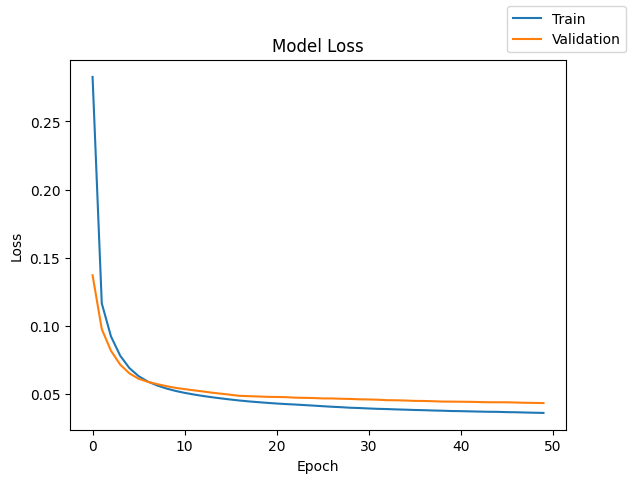

```python
plot(history,'loss')
```

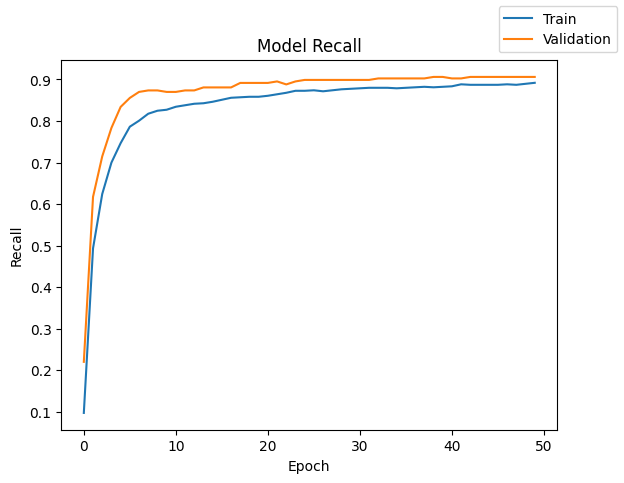

```python
plot(history,'recall')
```

```python
results.loc[3] = [2,'[20,10]','[ReLU,ReLU]',50,64,'Adam','[0.001,Default Beta_1 and Beta_2]',None,None,None,history.history["loss"][-1],history.history["val_loss"][-1],history.history["recall"][-1],history.history["val_recall"][-1],round(end-start,2)]

results
```

|  | # hidden layers | # neurons - hidden layer | activation function - hidden layer | # epochs | batch size | optimizer | learning rate, momentum | weight initializer | regularization | Class Weights | train loss | validation loss | train recall | validation recall | time (secs) |
| --- | --- | --- | --- | --- | --- | --- | --- | --- | --- | --- | --- | --- | --- | --- | --- |
| 0 | 1 | 20 | ReLU | 10 | 15000 | SGD | None | None | None | None | 0.747470 | 0.729348 | 0.445378 | 0.444043 | 1.52 |
| 1 | 1 | 20 | ReLU | 50 | 64 | SGD w/ Momentum | [-, 0.9] | None | None | None | 0.046026 | 0.053223 | 0.843938 | 0.841155 | 30.18 |
| 2 | 2 | [20,10] | [ReLU,ReLU] | 50 | 64 | SGD w/ Momentum | [0.0001, 0.8] | None | None | None | 0.151322 | 0.153274 | 0.146459 | 0.144404 | 29.35 |
| 3 | 2 | [20,10] | [ReLU,ReLU] | 50 | 64 | Adam | [0.001,Default Beta_1 and Beta_2] | None | None | None | 0.035853 | 0.043086 | 0.891957 | 0.906137 | 31.20 |

Observations Model 3:

- Loss:
  - The loss function has minimized well on both train and validation
  - Loss in the this model is lower than the previous models.
  - As the epochs increase, the difference between loss on train and validation increases, which may indicate slight overfitting.
- Recall:
  - Recall metric is good.
  - Recall in this model is better than the previous models.
  - As the epochs increase, recall on the train and validation converged.
- Training time:
  - Slightly longer than model 2.

## Model 4

- Changes:
  - Adding dropout in the first hidden layer (dropout_rate=0.5)

```python
# clears the current Keras session
tf.keras.backend.clear_session()

# initializing the neural network
model4 = Sequential()
# Adding hidden layer with ReLU activation
model4.add(Dense(20,activation="relu",input_shape=(X_train.shape[1],)))
# Adding dropout
model4.add(Dropout(0.5))
# Adding 2nd hidden layer with ReLU activation
model4.add(Dense(10,activation="relu"))
# Adding output layer with sigmoid activation for binary classification
model4.add(Dense(1, activation = 'sigmoid'))

# defining Adam as the optimizer to be used
optimizer = keras.optimizers.Adam(learning_rate=0.001)
# Using BinaryCrossentropy loss and recall metric for binary classification
model4.compile(loss=tf.keras.losses.BinaryCrossentropy(), optimizer=optimizer, metrics=["recall"])
```

```python
# Defining the batch size and number of epochs
batch_size = 64
epochs = 50

# time.time() returns the time in seconds since Thu Jan 1 00:00:00 1970.
start = time.time()

# Fitting the model.
history = model4.fit(
    X_train, y_train_reshaped,
    validation_data=(X_val,y_val_reshaped),
    batch_size=batch_size,
    epochs=epochs
)

# time.time() returns the time in seconds since Thu Jan 1 00:00:00 1970.
end = time.time()
```

```
235/235 ━━━━━━━━━━━━━━━━━━━━ 2s 3ms/step - loss: 0.4544 - recall: 0.1742 - val_loss: 0.1556 - val_recall: 0.0217
235/235 ━━━━━━━━━━━━━━━━━━━━ 1s 3ms/step - loss: 0.1782 - recall: 0.1775 - val_loss: 0.1192 - val_recall: 0.2924
235/235 ━━━━━━━━━━━━━━━━━━━━ 1s 2ms/step - loss: 0.1434 - recall: 0.3726 - val_loss: 0.1064 - val_recall: 0.4152
235/235 ━━━━━━━━━━━━━━━━━━━━ 0s 2ms/step - loss: 0.1229 - recall: 0.4410 - val_loss: 0.0959 - val_recall: 0.5307
235/235 ━━━━━━━━━━━━━━━━━━━━ 1s 2ms/step - loss: 0.1198 - recall: 0.4850 - val_loss: 0.0905 - val_recall: 0.5668
235/235 ━━━━━━━━━━━━━━━━━━━━ 1s 2ms/step - loss: 0.1121 - recall: 0.5253 - val_loss: 0.0828 - val_recall: 0.6245
235/235 ━━━━━━━━━━━━━━━━━━━━ 1s 2ms/step - loss: 0.1011 - recall: 0.5297 - val_loss: 0.0813 - val_recall: 0.5993
235/235 ━━━━━━━━━━━━━━━━━━━━ 0s 2ms/step - loss: 0.0948 - recall: 0.5820 - val_loss: 0.0758 - val_recall: 0.6643
235/235 ━━━━━━━━━━━━━━━━━━━━ 1s 2ms/step - loss: 0.0901 - recall: 0.6262 - val_loss: 0.0751 - val_recall: 0.6390
235/235 ━━━━━━━━━━━━━━━━━━━━ 1s 2ms/step - loss: 0.0921 - recall: 0.5911 - val_loss: 0.0702 - val_recall: 0.7256
235/235 ━━━━━━━━━━━━━━━━━━━━ 1s 2ms/step - loss: 0.0892 - recall: 0.6155 - val_loss: 0.0717 - val_recall: 0.6859
235/235 ━━━━━━━━━━━━━━━━━━━━ 1s 2ms/step - loss: 0.0878 - recall: 0.6032 - val_loss: 0.0698 - val_recall: 0.7076
235/235 ━━━━━━━━━━━━━━━━━━━━ 1s 2ms/step - loss: 0.0875 - recall: 0.6084 - val_loss: 0.0723 - val_recall: 0.6787
235/235 ━━━━━━━━━━━━━━━━━━━━ 1s 2ms/step - loss: 0.0879 - recall: 0.5991 - val_loss: 0.0692 - val_recall: 0.7148
235/235 ━━━━━━━━━━━━━━━━━━━━ 1s 2ms/step - loss: 0.0833 - recall: 0.6493 - val_loss: 0.0653 - val_recall: 0.7184
235/235 ━━━━━━━━━━━━━━━━━━━━ 0s 2ms/step - loss: 0.0810 - recall: 0.6576 - val_loss: 0.0671 - val_recall: 0.7004
235/235 ━━━━━━━━━━━━━━━━━━━━ 1s 2ms/step - loss: 0.0782 - recall: 0.6720 - val_loss: 0.0673 - val_recall: 0.7184
235/235 ━━━━━━━━━━━━━━━━━━━━ 0s 2ms/step - loss: 0.0805 - recall: 0.6597 - val_loss: 0.0673 - val_recall: 0.6968
235/235 ━━━━━━━━━━━━━━━━━━━━ 1s 2ms/step - loss: 0.0835 - recall: 0.6255 - val_loss: 0.0659 - val_recall: 0.7004
235/235 ━━━━━━━━━━━━━━━━━━━━ 1s 3ms/step - loss: 0.0775 - recall: 0.6729 - val_loss: 0.0648 - val_recall: 0.7112
235/235 ━━━━━━━━━━━━━━━━━━━━ 1s 3ms/step - loss: 0.0774 - recall: 0.6878 - val_loss: 0.0680 - val_recall: 0.7004
235/235 ━━━━━━━━━━━━━━━━━━━━ 1s 2ms/step - loss: 0.0837 - recall: 0.6298 - val_loss: 0.0651 - val_recall: 0.7148
235/235 ━━━━━━━━━━━━━━━━━━━━ 0s 2ms/step - loss: 0.0761 - recall: 0.6971 - val_loss: 0.0632 - val_recall: 0.7220
235/235 ━━━━━━━━━━━━━━━━━━━━ 0s 2ms/step - loss: 0.0739 - recall: 0.7178 - val_loss: 0.0635 - val_recall: 0.7148
235/235 ━━━━━━━━━━━━━━━━━━━━ 1s 2ms/step - loss: 0.0730 - recall: 0.7031 - val_loss: 0.0630 - val_recall: 0.7076
235/235 ━━━━━━━━━━━━━━━━━━━━ 1s 2ms/step - loss: 0.0755 - recall: 0.6840 - val_loss: 0.0612 - val_recall: 0.7292
235/235 ━━━━━━━━━━━━━━━━━━━━ 1s 2ms/step - loss: 0.0746 - recall: 0.6916 - val_loss: 0.0623 - val_recall: 0.7148
235/235 ━━━━━━━━━━━━━━━━━━━━ 0s 2ms/step - loss: 0.0789 - recall: 0.6642 - val_loss: 0.0614 - val_recall: 0.7256
235/235 ━━━━━━━━━━━━━━━━━━━━ 1s 2ms/step - loss: 0.0745 - recall: 0.6840 - val_loss: 0.0629 - val_recall: 0.7040
235/235 ━━━━━━━━━━━━━━━━━━━━ 0s 2ms/step - loss: 0.0727 - recall: 0.6800 - val_loss: 0.0617 - val_recall: 0.7148
235/235 ━━━━━━━━━━━━━━━━━━━━ 1s 2ms/step - loss: 0.0747 - recall: 0.6814 - val_loss: 0.0616 - val_recall: 0.7148
235/235 ━━━━━━━━━━━━━━━━━━━━ 1s 2ms/step - loss: 0.0681 - recall: 0.7150 - val_loss: 0.0610 - val_recall: 0.7112
235/235 ━━━━━━━━━━━━━━━━━━━━ 1s 2ms/step - loss: 0.0710 - recall: 0.6991 - val_loss: 0.0594 - val_recall: 0.7148
235/235 ━━━━━━━━━━━━━━━━━━━━ 0s 2ms/step - loss: 0.0674 - recall: 0.7166 - val_loss: 0.0625 - val_recall: 0.7112
235/235 ━━━━━━━━━━━━━━━━━━━━ 1s 2ms/step - loss: 0.0712 - recall: 0.6846 - val_loss: 0.0596 - val_recall: 0.7220
235/235 ━━━━━━━━━━━━━━━━━━━━ 1s 2ms/step - loss: 0.0700 - recall: 0.7028 - val_loss: 0.0589 - val_recall: 0.7256
235/235 ━━━━━━━━━━━━━━━━━━━━ 1s 2ms/step - loss: 0.0710 - recall: 0.7160 - val_loss: 0.0600 - val_recall: 0.7256
235/235 ━━━━━━━━━━━━━━━━━━━━ 0s 2ms/step - loss: 0.0743 - recall: 0.6970 - val_loss: 0.0646 - val_recall: 0.6679
235/235 ━━━━━━━━━━━━━━━━━━━━ 1s 2ms/step - loss: 0.0687 - recall: 0.7038 - val_loss: 0.0591 - val_recall: 0.7220
235/235 ━━━━━━━━━━━━━━━━━━━━ 1s 2ms/step - loss: 0.0660 - recall: 0.7371 - val_loss: 0.0587 - val_recall: 0.7220
235/235 ━━━━━━━━━━━━━━━━━━━━ 1s 3ms/step - loss: 0.0685 - recall: 0.7090 - val_loss: 0.0603 - val_recall: 0.7112
235/235 ━━━━━━━━━━━━━━━━━━━━ 1s 2ms/step - loss: 0.0681 - recall: 0.7172 - val_loss: 0.0604 - val_recall: 0.7040
235/235 ━━━━━━━━━━━━━━━━━━━━ 0s 2ms/step - loss: 0.0691 - recall: 0.7072 - val_loss: 0.0617 - val_recall: 0.7112
235/235 ━━━━━━━━━━━━━━━━━━━━ 1s 2ms/step - loss: 0.0687 - recall: 0.6956 - val_loss: 0.0602 - val_recall: 0.7256
235/235 ━━━━━━━━━━━━━━━━━━━━ 0s 2ms/step - loss: 0.0675 - recall: 0.7231 - val_loss: 0.0637 - val_recall: 0.6679
235/235 ━━━━━━━━━━━━━━━━━━━━ 1s 2ms/step - loss: 0.0694 - recall: 0.7051 - val_loss: 0.0617 - val_recall: 0.6931
235/235 ━━━━━━━━━━━━━━━━━━━━ 1s 2ms/step - loss: 0.0652 - recall: 0.7252 - val_loss: 0.0621 - val_recall: 0.7004
235/235 ━━━━━━━━━━━━━━━━━━━━ 1s 2ms/step - loss: 0.0682 - recall: 0.7108 - val_loss: 0.0626 - val_recall: 0.7004
235/235 ━━━━━━━━━━━━━━━━━━━━ 0s 2ms/step - loss: 0.0661 - recall: 0.7127 - val_loss: 0.0625 - val_recall: 0.6859
235/235 ━━━━━━━━━━━━━━━━━━━━ 0s 2ms/step - loss: 0.0669 - recall: 0.7222 - val_loss: 0.0601 - val_recall: 0.7184
```

```python
print("Time taken in seconds ",end-start)
```

```
Time taken in seconds  31.40449285507202
```

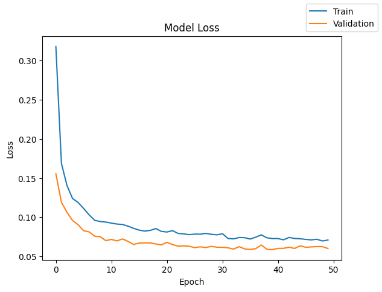

```python
plot(history,'loss')
```

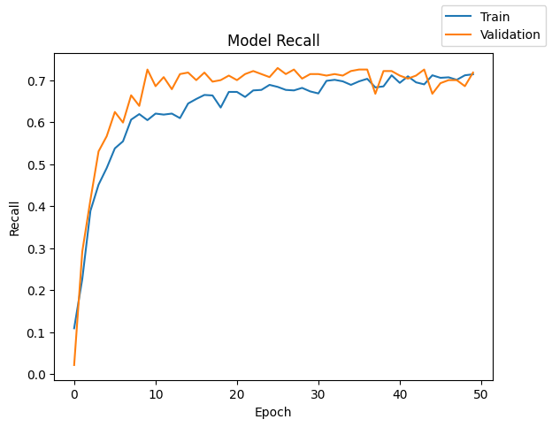

```python
plot(history,'recall')
```

```python
results.loc[4] = [2,'[20,10]','[ReLU,ReLU]',50,64,'Adam','[0.001,Default Beta_1 and Beta_2]',None,"Dropout(0.5) on first hidden layer",None,history.history["loss"][-1],history.history["val_loss"][-1],history.history["recall"][-1],history.history["val_recall"][-1],round(end-start,2)]

results
```

|  | # hidden layers | # neurons - hidden layer | activation function - hidden layer | # epochs | batch size | optimizer | learning rate, momentum | weight initializer | regularization | Class Weights | train loss | validation loss | train recall | validation recall | time (secs) |
| --- | --- | --- | --- | --- | --- | --- | --- | --- | --- | --- | --- | --- | --- | --- | --- |
| 0 | 1 | 20 | ReLU | 10 | 15000 | SGD | None | None | None | None | 0.747470 | 0.729348 | 0.445378 | 0.444043 | 1.52 |
| 1 | 1 | 20 | ReLU | 50 | 64 | SGD w/ Momentum | [-, 0.9] | None | None | None | 0.046026 | 0.053223 | 0.843938 | 0.841155 | 30.18 |
| 2 | 2 | [20,10] | [ReLU,ReLU] | 50 | 64 | SGD w/ Momentum | [0.0001, 0.8] | None | None | None | 0.151322 | 0.153274 | 0.146459 | 0.144404 | 29.35 |
| 3 | 2 | [20,10] | [ReLU,ReLU] | 50 | 64 | Adam | [0.001,Default Beta_1 and Beta_2] | None | None | None | 0.035853 | 0.043086 | 0.891957 | 0.906137 | 31.20 |
| 4 | 2 | [20,10] | [ReLU,ReLU] | 50 | 64 | Adam | [0.001,Default Beta_1 and Beta_2] | None | Dropout(0.5) on first hidden layer | None | 0.070974 | 0.060132 | 0.714286 | 0.718412 | 31.40 |

## Model 5

- Changes:
  - Removing dropout
  - Adding batch normalization layers for the outputs of the first and second hidden layers
  - Adding weight initialization (He - since I am using ReLU activations)

```python
# clears the current Keras session
tf.keras.backend.clear_session()

# initializing the neural network
model5 = Sequential()
# Adding hidden layer with ReLU activation
model5.add(Dense(20,activation="relu",kernel_initializer='he_normal',input_shape=(X_train.shape[1],)))
# Adding a batch normalization layer
model5.add(BatchNormalization())
# Adding 2nd hidden layer with ReLU activation
model5.add(Dense(10,activation="relu",kernel_initializer='he_normal'))
# Adding a batch normalization layer
model5.add(BatchNormalization())
# Adding output layer with sigmoid activation for binary classification
model5.add(Dense(1, activation = 'sigmoid'))

# defining Adam as the optimizer to be used
optimizer = keras.optimizers.Adam(learning_rate=0.001)
# Using BinaryCrossentropy loss and recall metric for binary classification
model5.compile(loss=tf.keras.losses.BinaryCrossentropy(), optimizer=optimizer, metrics=["recall"])
```

```python
# Defining the batch size and number of epochs
batch_size = 64
epochs = 50

# time.time() returns the time in seconds since Thu Jan 1 00:00:00 1970.
start = time.time()

# Fitting the model.
history = model5.fit(
    X_train, y_train_reshaped,
    validation_data=(X_val,y_val_reshaped),
    batch_size=batch_size,
    epochs=epochs
)

# time.time() returns the time in seconds since Thu Jan 1 00:00:00 1970.
end = time.time()
```

```
235/235 ━━━━━━━━━━━━━━━━━━━━ 2s 3ms/step - loss: 0.6690 - recall: 0.5878 - val_loss: 0.2472 - val_recall: 0.6426
235/235 ━━━━━━━━━━━━━━━━━━━━ 0s 2ms/step - loss: 0.2328 - recall: 0.7237 - val_loss: 0.1048 - val_recall: 0.6931
235/235 ━━━━━━━━━━━━━━━━━━━━ 1s 2ms/step - loss: 0.1027 - recall: 0.7501 - val_loss: 0.0730 - val_recall: 0.7473
235/235 ━━━━━━━━━━━━━━━━━━━━ 1s 2ms/step - loss: 0.0728 - recall: 0.7523 - val_loss: 0.0615 - val_recall: 0.7870
235/235 ━━━━━━━━━━━━━━━━━━━━ 1s 2ms/step - loss: 0.0625 - recall: 0.7772 - val_loss: 0.0564 - val_recall: 0.7906
235/235 ━━━━━━━━━━━━━━━━━━━━ 1s 3ms/step - loss: 0.0571 - recall: 0.7928 - val_loss: 0.0532 - val_recall: 0.8051
235/235 ━━━━━━━━━━━━━━━━━━━━ 1s 2ms/step - loss: 0.0535 - recall: 0.8008 - val_loss: 0.0515 - val_recall: 0.8195
235/235 ━━━━━━━━━━━━━━━━━━━━ 0s 2ms/step - loss: 0.0511 - recall: 0.8154 - val_loss: 0.0501 - val_recall: 0.8267
235/235 ━━━━━━━━━━━━━━━━━━━━ 1s 2ms/step - loss: 0.0491 - recall: 0.8345 - val_loss: 0.0487 - val_recall: 0.8303
235/235 ━━━━━━━━━━━━━━━━━━━━ 1s 2ms/step - loss: 0.0474 - recall: 0.8450 - val_loss: 0.0479 - val_recall: 0.8339
235/235 ━━━━━━━━━━━━━━━━━━━━ 1s 2ms/step - loss: 0.0461 - recall: 0.8486 - val_loss: 0.0471 - val_recall: 0.8448
235/235 ━━━━━━━━━━━━━━━━━━━━ 1s 2ms/step - loss: 0.0449 - recall: 0.8544 - val_loss: 0.0469 - val_recall: 0.8484
235/235 ━━━━━━━━━━━━━━━━━━━━ 1s 2ms/step - loss: 0.0440 - recall: 0.8561 - val_loss: 0.0462 - val_recall: 0.8556
235/235 ━━━━━━━━━━━━━━━━━━━━ 0s 2ms/step - loss: 0.0431 - recall: 0.8532 - val_loss: 0.0453 - val_recall: 0.8556
235/235 ━━━━━━━━━━━━━━━━━━━━ 1s 2ms/step - loss: 0.0422 - recall: 0.8577 - val_loss: 0.0450 - val_recall: 0.8556
235/235 ━━━━━━━━━━━━━━━━━━━━ 1s 2ms/step - loss: 0.0416 - recall: 0.8638 - val_loss: 0.0450 - val_recall: 0.8628
235/235 ━━━━━━━━━━━━━━━━━━━━ 1s 2ms/step - loss: 0.0408 - recall: 0.8694 - val_loss: 0.0443 - val_recall: 0.8700
235/235 ━━━━━━━━━━━━━━━━━━━━ 1s 2ms/step - loss: 0.0400 - recall: 0.8756 - val_loss: 0.0440 - val_recall: 0.8700
235/235 ━━━━━━━━━━━━━━━━━━━━ 1s 2ms/step - loss: 0.0396 - recall: 0.8721 - val_loss: 0.0436 - val_recall: 0.8736
235/235 ━━━━━━━━━━━━━━━━━━━━ 1s 2ms/step - loss: 0.0391 - recall: 0.8762 - val_loss: 0.0440 - val_recall: 0.8773
235/235 ━━━━━━━━━━━━━━━━━━━━ 1s 2ms/step - loss: 0.0386 - recall: 0.8810 - val_loss: 0.0435 - val_recall: 0.8773
235/235 ━━━━━━━━━━━━━━━━━━━━ 0s 2ms/step - loss: 0.0382 - recall: 0.8740 - val_loss: 0.0434 - val_recall: 0.8809
235/235 ━━━━━━━━━━━━━━━━━━━━ 1s 2ms/step - loss: 0.0377 - recall: 0.8864 - val_loss: 0.0431 - val_recall: 0.8809
235/235 ━━━━━━━━━━━━━━━━━━━━ 1s 2ms/step - loss: 0.0374 - recall: 0.8782 - val_loss: 0.0437 - val_recall: 0.8773
235/235 ━━━━━━━━━━━━━━━━━━━━ 1s 3ms/step - loss: 0.0371 - recall: 0.8865 - val_loss: 0.0439 - val_recall: 0.8773
235/235 ━━━━━━━━━━━━━━━━━━━━ 1s 2ms/step - loss: 0.0367 - recall: 0.8905 - val_loss: 0.0437 - val_recall: 0.8845
235/235 ━━━━━━━━━━━━━━━━━━━━ 1s 2ms/step - loss: 0.0366 - recall: 0.8885 - val_loss: 0.0442 - val_recall: 0.8845
235/235 ━━━━━━━━━━━━━━━━━━━━ 1s 2ms/step - loss: 0.0364 - recall: 0.8796 - val_loss: 0.0443 - val_recall: 0.8845
235/235 ━━━━━━━━━━━━━━━━━━━━ 1s 2ms/step - loss: 0.0363 - recall: 0.8902 - val_loss: 0.0444 - val_recall: 0.8845
235/235 ━━━━━━━━━━━━━━━━━━━━ 0s 2ms/step - loss: 0.0361 - recall: 0.8818 - val_loss: 0.0448 - val_recall: 0.8845
235/235 ━━━━━━━━━━━━━━━━━━━━ 1s 2ms/step - loss: 0.0357 - recall: 0.8943 - val_loss: 0.0447 - val_recall: 0.8809
235/235 ━━━━━━━━━━━━━━━━━━━━ 1s 2ms/step - loss: 0.0355 - recall: 0.8898 - val_loss: 0.0449 - val_recall: 0.8845
235/235 ━━━━━━━━━━━━━━━━━━━━ 1s 2ms/step - loss: 0.0356 - recall: 0.8805 - val_loss: 0.0456 - val_recall: 0.8845
235/235 ━━━━━━━━━━━━━━━━━━━━ 1s 2ms/step - loss: 0.0348 - recall: 0.8916 - val_loss: 0.0458 - val_recall: 0.8845
235/235 ━━━━━━━━━━━━━━━━━━━━ 1s 2ms/step - loss: 0.0346 - recall: 0.8899 - val_loss: 0.0460 - val_recall: 0.8881
235/235 ━━━━━━━━━━━━━━━━━━━━ 1s 2ms/step - loss: 0.0342 - recall: 0.8929 - val_loss: 0.0466 - val_recall: 0.8845
235/235 ━━━━━━━━━━━━━━━━━━━━ 1s 2ms/step - loss: 0.0340 - recall: 0.8935 - val_loss: 0.0465 - val_recall: 0.8881
235/235 ━━━━━━━━━━━━━━━━━━━━ 1s 2ms/step - loss: 0.0333 - recall: 0.8923 - val_loss: 0.0465 - val_recall: 0.8845
235/235 ━━━━━━━━━━━━━━━━━━━━ 1s 2ms/step - loss: 0.0329 - recall: 0.8935 - val_loss: 0.0468 - val_recall: 0.8773
235/235 ━━━━━━━━━━━━━━━━━━━━ 1s 2ms/step - loss: 0.0325 - recall: 0.8926 - val_loss: 0.0471 - val_recall: 0.8773
235/235 ━━━━━━━━━━━━━━━━━━━━ 1s 2ms/step - loss: 0.0324 - recall: 0.8973 - val_loss: 0.0469 - val_recall: 0.8773
235/235 ━━━━━━━━━━━━━━━━━━━━ 0s 2ms/step - loss: 0.0319 - recall: 0.9082 - val_loss: 0.0471 - val_recall: 0.8809
235/235 ━━━━━━━━━━━━━━━━━━━━ 1s 2ms/step - loss: 0.0317 - recall: 0.9029 - val_loss: 0.0471 - val_recall: 0.8809
235/235 ━━━━━━━━━━━━━━━━━━━━ 1s 3ms/step - loss: 0.0314 - recall: 0.9004 - val_loss: 0.0469 - val_recall: 0.8773
235/235 ━━━━━━━━━━━━━━━━━━━━ 1s 4ms/step - loss: 0.0313 - recall: 0.9076 - val_loss: 0.0471 - val_recall: 0.8773
235/235 ━━━━━━━━━━━━━━━━━━━━ 1s 2ms/step - loss: 0.0310 - recall: 0.8989 - val_loss: 0.0469 - val_recall: 0.8809
235/235 ━━━━━━━━━━━━━━━━━━━━ 1s 2ms/step - loss: 0.0307 - recall: 0.9051 - val_loss: 0.0470 - val_recall: 0.8809
235/235 ━━━━━━━━━━━━━━━━━━━━ 1s 2ms/step - loss: 0.0305 - recall: 0.9024 - val_loss: 0.0470 - val_recall: 0.8809
235/235 ━━━━━━━━━━━━━━━━━━━━ 1s 2ms/step - loss: 0.0304 - recall: 0.9037 - val_loss: 0.0471 - val_recall: 0.8845
235/235 ━━━━━━━━━━━━━━━━━━━━ 1s 2ms/step - loss: 0.0300 - recall: 0.9175 - val_loss: 0.0470 - val_recall: 0.8809
```

```python
print("Time taken in seconds ",end-start)
```

```
Time taken in seconds  32.611851930618286
```

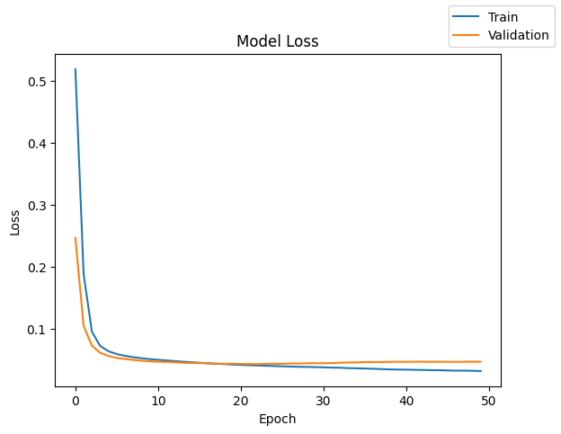

```python
plot(history,'loss')
```

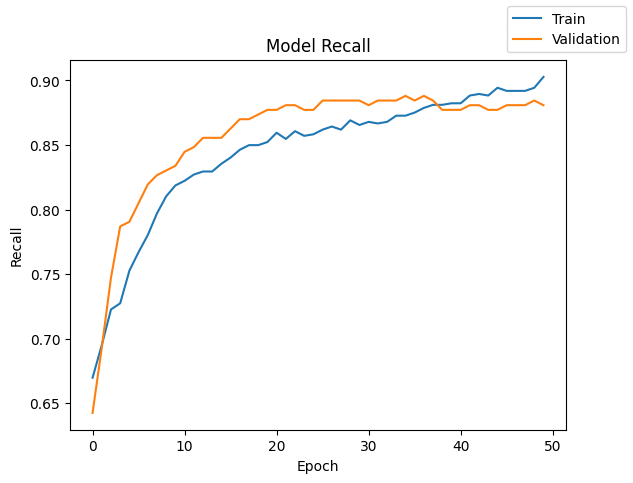

```python
plot(history,'recall')
```

```python
results.loc[5] = [2,'[20,10]','[ReLU,ReLU]',50,64,'Adam','[0.001,Default Beta_1 and Beta_2]',"He normal in both hidden layers","Batch normalization for both hidden layers",None,history.history["loss"][-1],history.history["val_loss"][-1],history.history["recall"][-1],history.history["val_recall"][-1],round(end-start,2)]

results
```

|  | # hidden layers | # neurons - hidden layer | activation function - hidden layer | # epochs | batch size | optimizer | learning rate, momentum | weight initializer | regularization | Class Weights | train loss | validation loss | train recall | validation recall | time (secs) |
| --- | --- | --- | --- | --- | --- | --- | --- | --- | --- | --- | --- | --- | --- | --- | --- |
| 0 | 1 | 20 | ReLU | 10 | 15000 | SGD | None | None | None | None | 0.747470 | 0.729348 | 0.445378 | 0.444043 | 1.52 |
| 1 | 1 | 20 | ReLU | 50 | 64 | SGD w/ Momentum | [-, 0.9] | None | None | None | 0.046026 | 0.053223 | 0.843938 | 0.841155 | 30.18 |
| 2 | 2 | [20,10] | [ReLU,ReLU] | 50 | 64 | SGD w/ Momentum | [0.0001, 0.8] | None | None | None | 0.151322 | 0.153274 | 0.146459 | 0.144404 | 29.35 |
| 3 | 2 | [20,10] | [ReLU,ReLU] | 50 | 64 | Adam | [0.001,Default Beta_1 and Beta_2] | None | None | None | 0.035853 | 0.043086 | 0.891957 | 0.906137 | 31.20 |
| 4 | 2 | [20,10] | [ReLU,ReLU] | 50 | 64 | Adam | [0.001,Default Beta_1 and Beta_2] | None | Dropout(0.5) on first hidden layer | None | 0.070974 | 0.060132 | 0.714286 | 0.718412 | 31.40 |
| 5 | 2 | [20,10] | [ReLU,ReLU] | 50 | 64 | Adam | [0.001,Default Beta_1 and Beta_2] | He normal in both hidden layers | Batch normalization for both hidden layers | None | 0.032076 | 0.047001 | 0.902761 | 0.880866 | 32.61 |

Observations Model 5:

- Loss:
  - This model minimized the loss function very well
  - This model has a similar loss to model 3
  - Loss for validation is slighlty higher than for trainig, indicating slight overfitting. But overall it has good generalization.
- Recall:
  - Recall metric is good for both train and validation
  - As epoch count increases, recall increases and converges for train and validation.
- Training time:
  - Few seconds longer than model 4.

## Model 6

- Changes:
  - Taking into account class weights (since Target variable is imbalanced)

```python
# Creating a class weight dictionary
cw_dict={0: (y_train.shape[0]/y_train.value_counts()[0]), 1: (y_train.shape[0]/y_train.value_counts()[1])}
```

```python
# clears the current Keras session
tf.keras.backend.clear_session()

# initializing the neural network
model6 = Sequential()
# Adding hidden layer with ReLU activation
model6.add(Dense(20,activation="relu",kernel_initializer='he_normal',input_shape=(X_train.shape[1],)))
# Adding a batch normalization layer
model6.add(BatchNormalization())
# Adding 2nd hidden layer with ReLU activation
model6.add(Dense(10,activation="relu",kernel_initializer='he_normal'))
# Adding a batch normalization layer
model6.add(BatchNormalization())
# Adding output layer with sigmoid activation for binary classification
model6.add(Dense(1, activation = 'sigmoid'))

# defining Adam as the optimizer to be used
optimizer = keras.optimizers.Adam(learning_rate=0.001)
# Using BinaryCrossentropy loss and recall metric for binary classification
model6.compile(loss=tf.keras.losses.BinaryCrossentropy(), optimizer=optimizer, metrics=["recall"])
```

```python
# Defining the batch size and number of epochs
batch_size = 64
epochs = 50

# time.time() returns the time in seconds since Thu Jan 1 00:00:00 1970.
start = time.time()

# Fitting the model.
history = model6.fit(
    X_train, y_train_reshaped,
    validation_data=(X_val,y_val_reshaped),
    batch_size=batch_size,
    epochs=epochs,
    class_weight=cw_dict
)

# time.time() returns the time in seconds since Thu Jan 1 00:00:00 1970.
end = time.time()
```

```
235/235 ━━━━━━━━━━━━━━━━━━━━ 2s 3ms/step - loss: 1.1713 - recall: 0.7649 - val_loss: 0.4025 - val_recall: 0.8953
235/235 ━━━━━━━━━━━━━━━━━━━━ 1s 2ms/step - loss: 0.6436 - recall: 0.8947 - val_loss: 0.2520 - val_recall: 0.8917
235/235 ━━━━━━━━━━━━━━━━━━━━ 1s 2ms/step - loss: 0.5208 - recall: 0.9022 - val_loss: 0.1914 - val_recall: 0.8917
235/235 ━━━━━━━━━━━━━━━━━━━━ 1s 2ms/step - loss: 0.4637 - recall: 0.9015 - val_loss: 0.1769 - val_recall: 0.8917
235/235 ━━━━━━━━━━━━━━━━━━━━ 1s 2ms/step - loss: 0.4290 - recall: 0.9033 - val_loss: 0.1616 - val_recall: 0.8989
235/235 ━━━━━━━━━━━━━━━━━━━━ 1s 2ms/step - loss: 0.4079 - recall: 0.9071 - val_loss: 0.1444 - val_recall: 0.8989
235/235 ━━━━━━━━━━━━━━━━━━━━ 1s 2ms/step - loss: 0.3901 - recall: 0.9075 - val_loss: 0.1400 - val_recall: 0.8989
235/235 ━━━━━━━━━━━━━━━━━━━━ 1s 3ms/step - loss: 0.3773 - recall: 0.9168 - val_loss: 0.1319 - val_recall: 0.8953
235/235 ━━━━━━━━━━━━━━━━━━━━ 1s 3ms/step - loss: 0.3677 - recall: 0.9176 - val_loss: 0.1298 - val_recall: 0.9025
235/235 ━━━━━━━━━━━━━━━━━━━━ 1s 2ms/step - loss: 0.3560 - recall: 0.9179 - val_loss: 0.1265 - val_recall: 0.9025
235/235 ━━━━━━━━━━━━━━━━━━━━ 1s 2ms/step - loss: 0.3489 - recall: 0.9206 - val_loss: 0.1238 - val_recall: 0.9025
235/235 ━━━━━━━━━━━━━━━━━━━━ 1s 2ms/step - loss: 0.3416 - recall: 0.9227 - val_loss: 0.1188 - val_recall: 0.9025
235/235 ━━━━━━━━━━━━━━━━━━━━ 1s 2ms/step - loss: 0.3345 - recall: 0.9254 - val_loss: 0.1153 - val_recall: 0.9025
235/235 ━━━━━━━━━━━━━━━━━━━━ 1s 2ms/step - loss: 0.3288 - recall: 0.9283 - val_loss: 0.1139 - val_recall: 0.8989
235/235 ━━━━━━━━━━━━━━━━━━━━ 1s 2ms/step - loss: 0.3252 - recall: 0.9259 - val_loss: 0.1125 - val_recall: 0.8989
235/235 ━━━━━━━━━━━━━━━━━━━━ 1s 2ms/step - loss: 0.3191 - recall: 0.9315 - val_loss: 0.1107 - val_recall: 0.8989
235/235 ━━━━━━━━━━━━━━━━━━━━ 1s 2ms/step - loss: 0.3177 - recall: 0.9335 - val_loss: 0.1091 - val_recall: 0.9025
235/235 ━━━━━━━━━━━━━━━━━━━━ 1s 2ms/step - loss: 0.3142 - recall: 0.9307 - val_loss: 0.1094 - val_recall: 0.9025
235/235 ━━━━━━━━━━━━━━━━━━━━ 0s 2ms/step - loss: 0.3119 - recall: 0.9306 - val_loss: 0.1081 - val_recall: 0.9025
235/235 ━━━━━━━━━━━━━━━━━━━━ 1s 2ms/step - loss: 0.3100 - recall: 0.9321 - val_loss: 0.1072 - val_recall: 0.9025
235/235 ━━━━━━━━━━━━━━━━━━━━ 0s 2ms/step - loss: 0.3062 - recall: 0.9317 - val_loss: 0.1072 - val_recall: 0.9025
235/235 ━━━━━━━━━━━━━━━━━━━━ 1s 2ms/step - loss: 0.3020 - recall: 0.9305 - val_loss: 0.1070 - val_recall: 0.9025
235/235 ━━━━━━━━━━━━━━━━━━━━ 1s 2ms/step - loss: 0.2998 - recall: 0.9297 - val_loss: 0.1056 - val_recall: 0.9025
235/235 ━━━━━━━━━━━━━━━━━━━━ 1s 2ms/step - loss: 0.3004 - recall: 0.9312 - val_loss: 0.1058 - val_recall: 0.9025
235/235 ━━━━━━━━━━━━━━━━━━━━ 1s 2ms/step - loss: 0.2959 - recall: 0.9344 - val_loss: 0.1041 - val_recall: 0.9025
235/235 ━━━━━━━━━━━━━━━━━━━━ 1s 2ms/step - loss: 0.2940 - recall: 0.9332 - val_loss: 0.1018 - val_recall: 0.9025
235/235 ━━━━━━━━━━━━━━━━━━━━ 1s 3ms/step - loss: 0.2909 - recall: 0.9330 - val_loss: 0.1041 - val_recall: 0.9025
235/235 ━━━━━━━━━━━━━━━━━━━━ 1s 2ms/step - loss: 0.2899 - recall: 0.9331 - val_loss: 0.1047 - val_recall: 0.9025
235/235 ━━━━━━━━━━━━━━━━━━━━ 1s 2ms/step - loss: 0.2871 - recall: 0.9346 - val_loss: 0.1021 - val_recall: 0.9025
235/235 ━━━━━━━━━━━━━━━━━━━━ 1s 2ms/step - loss: 0.2860 - recall: 0.9321 - val_loss: 0.1055 - val_recall: 0.9025
235/235 ━━━━━━━━━━━━━━━━━━━━ 1s 2ms/step - loss: 0.2827 - recall: 0.9352 - val_loss: 0.1045 - val_recall: 0.9025
235/235 ━━━━━━━━━━━━━━━━━━━━ 1s 2ms/step - loss: 0.2801 - recall: 0.9343 - val_loss: 0.1041 - val_recall: 0.9025
235/235 ━━━━━━━━━━━━━━━━━━━━ 1s 2ms/step - loss: 0.2776 - recall: 0.9358 - val_loss: 0.1051 - val_recall: 0.9025
235/235 ━━━━━━━━━━━━━━━━━━━━ 1s 2ms/step - loss: 0.2753 - recall: 0.9356 - val_loss: 0.1024 - val_recall: 0.9025
235/235 ━━━━━━━━━━━━━━━━━━━━ 1s 2ms/step - loss: 0.2709 - recall: 0.9392 - val_loss: 0.1027 - val_recall: 0.9025
235/235 ━━━━━━━━━━━━━━━━━━━━ 1s 2ms/step - loss: 0.2733 - recall: 0.9338 - val_loss: 0.1032 - val_recall: 0.9025
235/235 ━━━━━━━━━━━━━━━━━━━━ 1s 2ms/step - loss: 0.2696 - recall: 0.9344 - val_loss: 0.1034 - val_recall: 0.9025
235/235 ━━━━━━━━━━━━━━━━━━━━ 1s 2ms/step - loss: 0.2666 - recall: 0.9335 - val_loss: 0.1055 - val_recall: 0.9025
235/235 ━━━━━━━━━━━━━━━━━━━━ 1s 3ms/step - loss: 0.2627 - recall: 0.9377 - val_loss: 0.1022 - val_recall: 0.9025
235/235 ━━━━━━━━━━━━━━━━━━━━ 1s 2ms/step - loss: 0.2615 - recall: 0.9381 - val_loss: 0.1028 - val_recall: 0.9025
235/235 ━━━━━━━━━━━━━━━━━━━━ 1s 2ms/step - loss: 0.2597 - recall: 0.9394 - val_loss: 0.1041 - val_recall: 0.9025
235/235 ━━━━━━━━━━━━━━━━━━━━ 1s 2ms/step - loss: 0.2568 - recall: 0.9376 - val_loss: 0.1051 - val_recall: 0.9025
235/235 ━━━━━━━━━━━━━━━━━━━━ 1s 2ms/step - loss: 0.2592 - recall: 0.9394 - val_loss: 0.1046 - val_recall: 0.9025
235/235 ━━━━━━━━━━━━━━━━━━━━ 1s 3ms/step - loss: 0.2538 - recall: 0.9391 - val_loss: 0.1060 - val_recall: 0.9025
235/235 ━━━━━━━━━━━━━━━━━━━━ 1s 3ms/step - loss: 0.2534 - recall: 0.9380 - val_loss: 0.1071 - val_recall: 0.9025
235/235 ━━━━━━━━━━━━━━━━━━━━ 1s 2ms/step - loss: 0.2477 - recall: 0.9385 - val_loss: 0.1052 - val_recall: 0.9025
235/235 ━━━━━━━━━━━━━━━━━━━━ 1s 2ms/step - loss: 0.2491 - recall: 0.9374 - val_loss: 0.1039 - val_recall: 0.9025
235/235 ━━━━━━━━━━━━━━━━━━━━ 1s 2ms/step - loss: 0.2501 - recall: 0.9370 - val_loss: 0.1036 - val_recall: 0.9025
235/235 ━━━━━━━━━━━━━━━━━━━━ 1s 2ms/step - loss: 0.2456 - recall: 0.9393 - val_loss: 0.1011 - val_recall: 0.9025
235/235 ━━━━━━━━━━━━━━━━━━━━ 1s 2ms/step - loss: 0.2440 - recall: 0.9370 - val_loss: 0.1043 - val_recall: 0.9025
```

```python
print("Time taken in seconds ",end-start)
```

```
Time taken in seconds  34.46067547798157
```

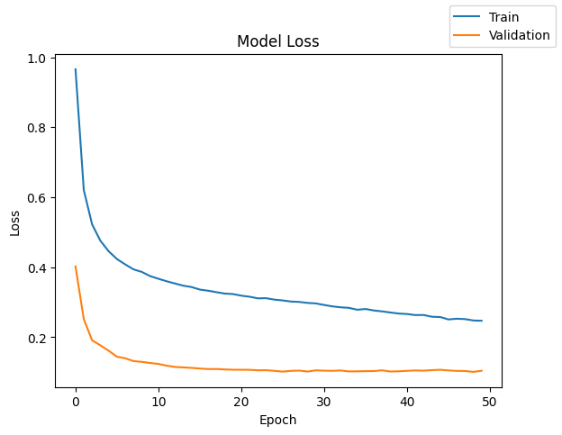

```python
plot(history,'loss')
```

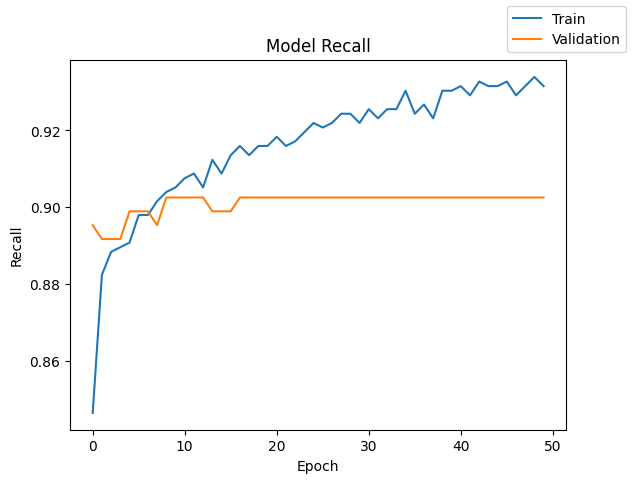

```python
plot(history,'recall')
```

```python
results.loc[6] = [2,'[20,10]','[ReLU,ReLU]',50,64,'Adam','[0.001,Default Beta_1 and Beta_2]',"He normal in both hidden layers","Batch normalization for both hidden layers","Yes",history.history["loss"][-1],history.history["val_loss"][-1],history.history["recall"][-1],history.history["val_recall"][-1],round(end-start,2)]

results
```

|  | # hidden layers | # neurons - hidden layer | activation function - hidden layer | # epochs | batch size | optimizer | learning rate, momentum | weight initializer | regularization | Class Weights | train loss | validation loss | train recall | validation recall | time (secs) |
| --- | --- | --- | --- | --- | --- | --- | --- | --- | --- | --- | --- | --- | --- | --- | --- |
| 0 | 1 | 20 | ReLU | 10 | 15000 | SGD | None | None | None | None | 0.747470 | 0.729348 | 0.445378 | 0.444043 | 1.52 |
| 1 | 1 | 20 | ReLU | 50 | 64 | SGD w/ Momentum | [-, 0.9] | None | None | None | 0.046026 | 0.053223 | 0.843938 | 0.841155 | 30.18 |
| 2 | 2 | [20,10] | [ReLU,ReLU] | 50 | 64 | SGD w/ Momentum | [0.0001, 0.8] | None | None | None | 0.151322 | 0.153274 | 0.146459 | 0.144404 | 29.35 |
| 3 | 2 | [20,10] | [ReLU,ReLU] | 50 | 64 | Adam | [0.001,Default Beta_1 and Beta_2] | None | None | None | 0.035853 | 0.043086 | 0.891957 | 0.906137 | 31.20 |
| 4 | 2 | [20,10] | [ReLU,ReLU] | 50 | 64 | Adam | [0.001,Default Beta_1 and Beta_2] | None | Dropout(0.5) on first hidden layer | None | 0.070974 | 0.060132 | 0.714286 | 0.718412 | 31.40 |
| 5 | 2 | [20,10] | [ReLU,ReLU] | 50 | 64 | Adam | [0.001,Default Beta_1 and Beta_2] | He normal in both hidden layers | Batch normalization for both hidden layers | None | 0.032076 | 0.047001 | 0.902761 | 0.880866 | 32.61 |
| 6 | 2 | [20,10] | [ReLU,ReLU] | 50 | 64 | Adam | [0.001,Default Beta_1 and Beta_2] | He normal in both hidden layers | Batch normalization for both hidden layers | Yes | 0.247244 | 0.104322 | 0.931573 | 0.902527 | 34.46 |

Observations Model 6:

# **Model Performance Comparison and Final Model Selection**

Now, in order to select the final model, we will compare the performances of all the models for the training and validation sets.

```python
# Printing the results
results
```

|  | # hidden layers | # neurons - hidden layer | activation function - hidden layer | # epochs | batch size | optimizer | learning rate, momentum | weight initializer | regularization | Class Weights | train loss | validation loss | train recall | validation recall | time (secs) |
| --- | --- | --- | --- | --- | --- | --- | --- | --- | --- | --- | --- | --- | --- | --- | --- |
| 0 | 1 | 20 | ReLU | 10 | 15000 | SGD | None | None | None | None | 0.747470 | 0.729348 | 0.445378 | 0.444043 | 1.52 |
| 1 | 1 | 20 | ReLU | 50 | 64 | SGD w/ Momentum | [-, 0.9] | None | None | None | 0.046026 | 0.053223 | 0.843938 | 0.841155 | 30.18 |
| 2 | 2 | [20,10] | [ReLU,ReLU] | 50 | 64 | SGD w/ Momentum | [0.0001, 0.8] | None | None | None | 0.151322 | 0.153274 | 0.146459 | 0.144404 | 29.35 |
| 3 | 2 | [20,10] | [ReLU,ReLU] | 50 | 64 | Adam | [0.001,Default Beta_1 and Beta_2] | None | None | None | 0.035853 | 0.043086 | 0.891957 | 0.906137 | 31.20 |
| 4 | 2 | [20,10] | [ReLU,ReLU] | 50 | 64 | Adam | [0.001,Default Beta_1 and Beta_2] | None | Dropout(0.5) on first hidden layer | None | 0.070974 | 0.060132 | 0.714286 | 0.718412 | 31.40 |
| 5 | 2 | [20,10] | [ReLU,ReLU] | 50 | 64 | Adam | [0.001,Default Beta_1 and Beta_2] | He normal in both hidden layers | Batch normalization for both hidden layers | None | 0.032076 | 0.047001 | 0.902761 | 0.880866 | 32.61 |
| 6 | 2 | [20,10] | [ReLU,ReLU] | 50 | 64 | Adam | [0.001,Default Beta_1 and Beta_2] | He normal in both hidden layers | Batch normalization for both hidden layers | Yes | 0.247244 | 0.104322 | 0.931573 | 0.902527 | 34.46 |

Final Model selection: Model 3

Now, let's check the performance of the final model on the test set.

```python
# Checking the performance of model 3 on the test set
model3.evaluate(X_test,y_test,return_dict=True)
```

```
157/157 ━━━━━━━━━━━━━━━━━━━━ 0s 1ms/step - loss: 0.0556 - recall: 0.8334
```

```
{'loss': 0.05917278304696083, 'recall': 0.847517728805542}
```

# **Actionable Insights and Recommendations**

- Actionable insights:
  - High Recall Indicates Effective Failure Detection
    - A recall of 0.8475 means the model correctly identifies around 85% of real failures.
    - Since false negatives lead to replacement costs, which are the most expensive, this high recall directly contributes to cost reduction by preventing undetected failures.
  - Low Loss Suggests Strong Model Fit
    - A low binary crossentropy loss (0.059) indicates that the predicted probabilities are well-calibrated and confident, meaning the model makes few incorrect or uncertain predictions.
    - This improves trustworthiness of failure predictions for field deployment.
  - Balanced Cost Trade-Off
    - False positives (inspections) and true positives (repairs) are much cheaper than false negatives (replacements).
    - Even if the model occasionally triggers unnecessary inspections (false positives), it is a worthwhile trade-off compared to the cost of undetected failures.
- Recommendations
  - Deploy the Model as a Real-Time Monitoring Tool
    - Integrate the neural network with the turbine's live sensor system to continuously assess generator health.
    - Use model output to schedule preventive maintenance before an actual breakdown occurs.
  - Prioritize Failures Flagged by the Model
    - Automatically generate repair tickets for these cases.
    - Flag them for immediate inspection and repair.
  - Build a Cost-Aware Maintenance Pipeline
    - Combine predictions with cost estimates (repair vs. replacement vs. inspection).
    - Create a maintenance prioritization strategy based on predicted probabilities:
      - High probability of failure → urgent repair.
      - Medium probability → inspect.
      - Low probability → monitor.
  - Continue to Track False Positives
    - Even though false positives are relatively cheap (inspections), they may lead to resource inefficiencies.
    - Recommend tracking inspection outcomes to:
      - Refine the model further (potential for active learning).
      - Improve precision without sacrificing recall.
  - Evaluate Model Robustness Over Time
    - Begin with pilot deployment on a limited number of turbines.
    - Monitor model drift or changing failure patterns over time, especially under new environmental conditions or component updates.
    - Retrain regularly on fresh sensor data.